# ICCB Species distribution modelling and validation

# First Model: GLM model fitting

```r
# Make a folder to save outputs
dir.create("Outputs/GLM_outputs", showWarnings = F)
```

## Null model

Null model: no explanatory variables or predictors are included.

It is always helpful to create a null model as a benchmark to assess how the inclusion of explanatory variables improves the model.

```r
# Fit a null model with only the intercept
null_model <- glm(Presence ~ 1,
                  data = train_PB_covs,
                  family = binomial(link = "logit"))

# Check the model results
summary(null_model)
```

```
Call:
glm(formula = Presence ~ 1, family = binomial(link = "logit"),
    data = train_PB_covs)

Coefficients:
            Estimate Std. Error z value Pr(>|z|)
(Intercept)  4.07488    0.02636   154.6   <2e-16 ***
---
Signif. codes:  0 '***' 0.001 '**' 0.01 '*' 0.05 '.' 0.1 ' ' 1

(Dispersion parameter for binomial family taken to be 1)

    Null deviance: 14884  on 87610  degrees of freedom
Residual deviance: 14884  on 87610  degrees of freedom
AIC: 14886

Number of Fisher Scoring iterations: 7
```

## GLM Model 1 - expert variables

```r
glm_model_1 <- glm(Presence ~
                     BIO5_Max_Temp_Warmest_Month +
                     BIO6_Min_Temp_Coldest_Month +
                     BIO12_Annual_Precipitation +
                     BIO15_Precip_Seasonality,
                   data=train_PB_covs_thinned,
                   family = binomial(link = "logit"))

# Check the model results
summary(glm_model_1)
```

```
Call:
glm(formula = Presence ~ BIO5_Max_Temp_Warmest_Month + BIO6_Min_Temp_Coldest_Month +
    BIO12_Annual_Precipitation + BIO15_Precip_Seasonality, family = binomial(link = "logit"),
    data = train_PB_covs_thinned)

Coefficients:
                              Estimate Std. Error z value Pr(>|z|)
(Intercept)                 -6.4382514  1.5863788  -4.058 4.94e-05 ***
BIO5_Max_Temp_Warmest_Month -0.6066972  0.0524073 -11.577  < 2e-16 ***
BIO6_Min_Temp_Coldest_Month  0.8786225  0.0283030  31.043  < 2e-16 ***
BIO12_Annual_Precipitation  -0.0029178  0.0002755 -10.592  < 2e-16 ***
BIO15_Precip_Seasonality     0.2481506  0.0108872  22.793  < 2e-16 ***
---
Signif. codes:  0 '***' 0.001 '**' 0.01 '*' 0.05 '.' 0.1 ' ' 1

(Dispersion parameter for binomial family taken to be 1)

    Null deviance: 8758.5  on 11463  degrees of freedom
Residual deviance: 5702.2  on 11459  degrees of freedom
AIC: 5712.2

Number of Fisher Scoring iterations: 6
```

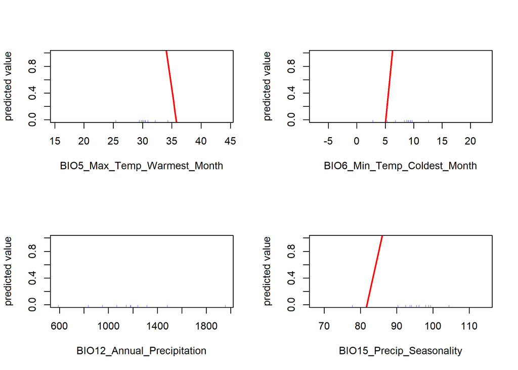

```r
# These response curves don't look very helpful
dismo::response(glm_model_1)
```

## GLM Model 2 - expert variables with quadratics

In this model, we include quadratic terms for the covariates. This is a common approach in species distribution modelling to account for non-linear relationships between the predictors and the response variable. This increases the complexity of the model and allows for more flexibility in fitting the data.

```r
glm_model_2 <- glm(Presence ~
                     BIO5_Max_Temp_Warmest_Month + I(BIO5_Max_Temp_Warmest_Month^2) +
                     BIO6_Min_Temp_Coldest_Month + I(BIO6_Min_Temp_Coldest_Month^2) +
                     BIO12_Annual_Precipitation + I(BIO12_Annual_Precipitation^2) +
                     BIO15_Precip_Seasonality + I(BIO15_Precip_Seasonality^2),
                   data=train_PB_covs_thinned,
                   family = binomial(link = "logit"))

# Check the model results
summary(glm_model_2)
```

```
Call:
glm(formula = Presence ~ BIO5_Max_Temp_Warmest_Month + I(BIO5_Max_Temp_Warmest_Month^2) +
    BIO6_Min_Temp_Coldest_Month + I(BIO6_Min_Temp_Coldest_Month^2) +
    BIO12_Annual_Precipitation + I(BIO12_Annual_Precipitation^2) +
    BIO15_Precip_Seasonality + I(BIO15_Precip_Seasonality^2),
    family = binomial(link = "logit"), data = train_PB_covs_thinned)

Coefficients:
                                   Estimate Std. Error z value Pr(>|z|)
(Intercept)                      -8.261e+01  1.857e+01  -4.448 8.66e-06 ***
BIO5_Max_Temp_Warmest_Month      -1.284e+00  1.207e+00  -1.064   0.2874
I(BIO5_Max_Temp_Warmest_Month^2)  1.218e-02  1.953e-02   0.623   0.5330
BIO6_Min_Temp_Coldest_Month      -1.010e+00  1.917e-01  -5.268 1.38e-07 ***
I(BIO6_Min_Temp_Coldest_Month^2)  1.384e-01  1.286e-02  10.758  < 2e-16 ***
BIO12_Annual_Precipitation        1.053e-03  1.964e-03   0.536   0.5917
I(BIO12_Annual_Precipitation^2)  -1.353e-06  7.008e-07  -1.931   0.0535 .
BIO15_Precip_Seasonality          2.036e+00  2.384e-01   8.539  < 2e-16 ***
I(BIO15_Precip_Seasonality^2)    -8.983e-03  1.272e-03  -7.059 1.67e-12 ***
---
Signif. codes:  0 '***' 0.001 '**' 0.01 '*' 0.05 '.' 0.1 ' ' 1

(Dispersion parameter for binomial family taken to be 1)

    Null deviance: 8758.5  on 11463  degrees of freedom
Residual deviance: 5550.0  on 11455  degrees of freedom
AIC: 5568

Number of Fisher Scoring iterations: 6
```

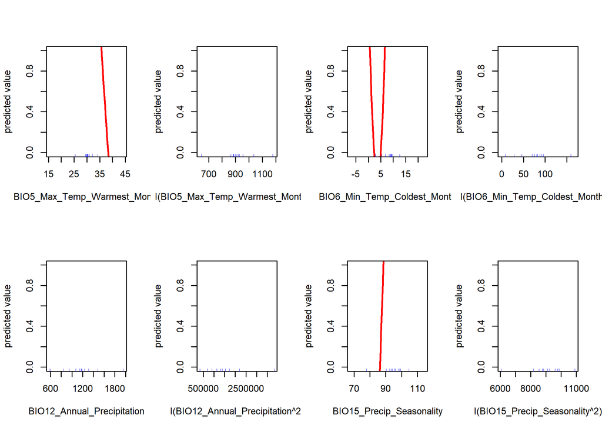

```r
# These response curves don't look very helpful
dismo::response(glm_model_2)
```

## Model effect evaluation

Here we use a function presented in an EcoCommons Australia notebook to evaluate the model performance. The notebook can be found on their GitHub: https://github.com/EcoCommonsAustralia/notebooks/tree/main/notebooks.

```r
# Function to plot effect size graph
plot_effect_size <- function(glm_model) {
  # Check if required libraries are installed
  if (!requireNamespace("ggplot2", quietly = TRUE)) {
    stop("Please install the 'ggplot2' package to use this function.")
  }
  library(ggplot2)

  # Extract effect sizes (coefficients) from the model
  coefs <- summary(glm_model)$coefficients
  effect_sizes <- data.frame(
    Variable = rownames(coefs)[-1],  # Exclude the intercept
    Effect_Size = coefs[-1, "Estimate"],
    Std_Error = coefs[-1, "Std. Error"]
  )

  # Sort by effect size
  effect_sizes <- effect_sizes[order(-abs(effect_sizes$Effect_Size)), ]

  # Plot the effect sizes with error bars
  ggplot(effect_sizes, aes(x = reorder(Variable, Effect_Size), y = Effect_Size)) +
    geom_bar(stat = "identity", fill = "#11aa96") +
    geom_errorbar(aes(ymin = Effect_Size - Std_Error, ymax = Effect_Size + Std_Error), width = 0.2) +
    coord_flip() +
    labs(
      title = "Effect Sizes of Variables",
      x = "Variable",
      y = "Effect Size (Coefficient Estimate)"
    ) +
    theme_minimal()
}
```

## Use the function to check the effect sizes

We need to be careful when interpreting the effect sizes of models with quadratic terms however, as the response curve depends on the linear and the quadratic term.

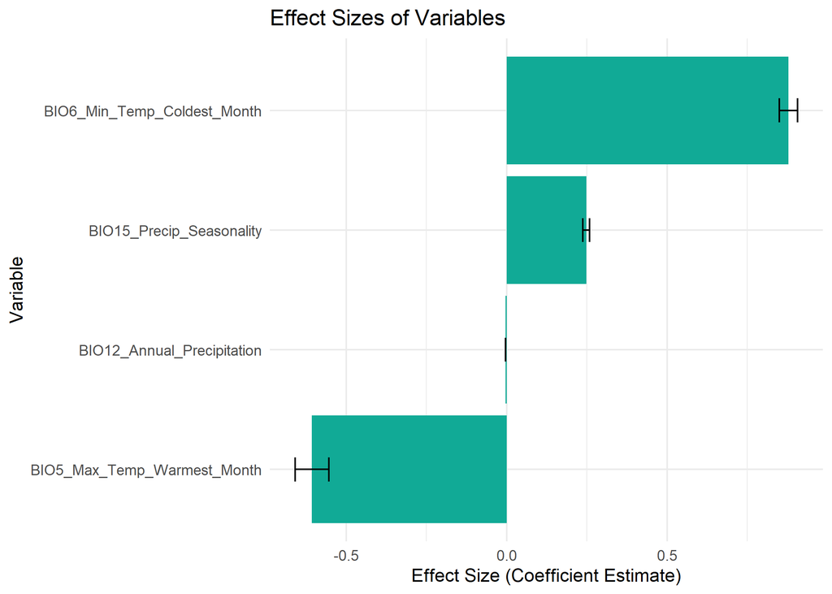

```r
# Example usage of effect size plot
plot_effect_size(glm_model_1)
```

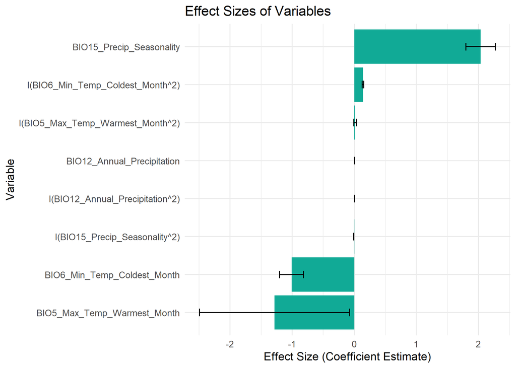

```r
plot_effect_size(glm_model_2)
```

## Response curves

Again, we can use a function from the EcoCommons notebook to plot the response curves from the model, although for quadratics we need to adjust the function or use something else.

```r
plot_species_response <- function(glm_model, predictors, data) {
  # Check if required libraries are installed
  if (!requireNamespace("ggplot2", quietly = TRUE) || !requireNamespace("gridExtra", quietly = TRUE)) {
    stop("Please install the 'ggplot2' and 'gridExtra' packages to use this function.")
  }
  library(ggplot2)
  library(gridExtra)

  # Create empty list to store response plots
  response_plots <- list()

  # Loop through each predictor variable
  for (predictor in predictors) {
    # Create new data frame to vary predictor while keeping others constant
    pred_range <- seq(
      min(data[[predictor]], na.rm = TRUE),
      max(data[[predictor]], na.rm = TRUE),
      length.out = 100
    )
    const_data <- data[1, , drop = FALSE]  # Use first row to keep other predictors constant
    response_data <- const_data[rep(1, 100), ]  # Duplicate the row
    response_data[[predictor]] <- pred_range

    # Predict probabilities
    predicted_response <- predict(glm_model, newdata = response_data, type = "response")

    # Create data frame for plotting
    plot_data <- data.frame(
      Predictor_Value = pred_range,
      Predicted_Probability = predicted_response
    )

    # Add presence and absence data
    presence_absence_data <- data.frame(
      Predictor_Value = data[[predictor]],
      Presence_Absence = data$Presence
    )

    # Generate the response plot
    p <- ggplot() +

      geom_line(data = plot_data,
                aes(x = Predictor_Value, y = Predicted_Probability),
                color = "#61c6fa", linewidth = 1) +

      geom_point(data = presence_absence_data[presence_absence_data$Presence_Absence == 1, ],
                 aes(x = Predictor_Value, y = Presence_Absence),
                 color = "#11aa96", alpha = 0.6) +

      geom_point(data = presence_absence_data[presence_absence_data$Presence_Absence == 0, ],
                 aes(x = Predictor_Value, y = Presence_Absence),
                 color = "#f6aa70", alpha = 0.6) +

      labs(x = predictor, y = NULL) +
      theme_minimal() +
      theme(axis.title.y = element_blank())

    # Store the plot in the list
    response_plots[[predictor]] <- p
  }

  # Arrange all plots in one combined plot with a single shared y-axis label
  grid.arrange(
    grobs = response_plots,
    ncol = 3,
    left = "Predicted Probability / Presence-Absence"
  )
}
```

## Use the response curve function

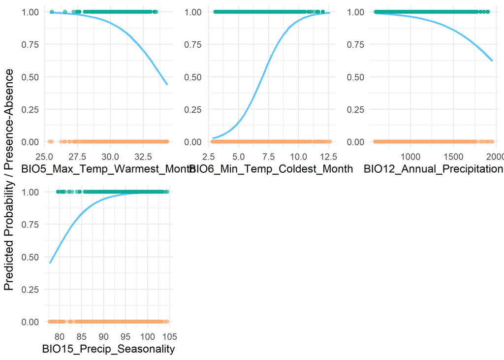

```r
predictors <- c("BIO5_Max_Temp_Warmest_Month",
                "BIO6_Min_Temp_Coldest_Month",
                "BIO12_Annual_Precipitation",
                "BIO15_Precip_Seasonality")

plot_species_response(glm_model_1, predictors, train_PB_covs_thinned)
```

### Model 1 partial responses

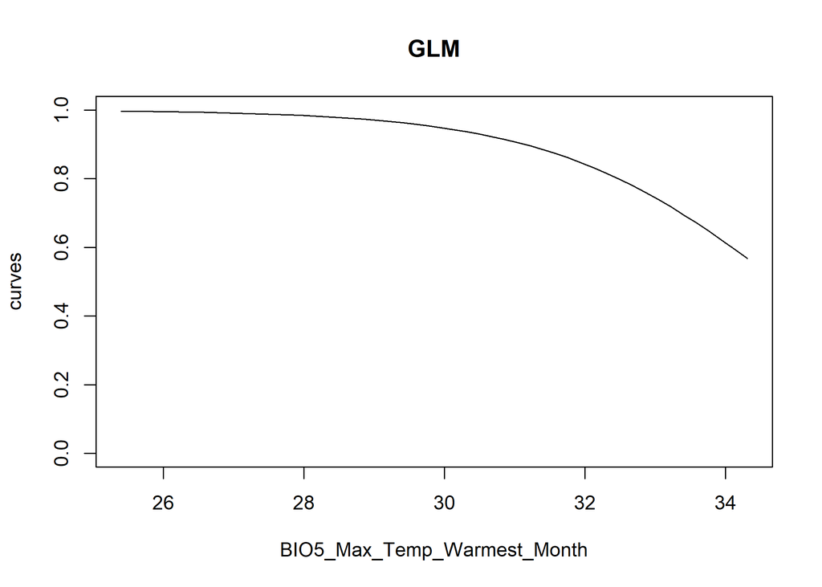

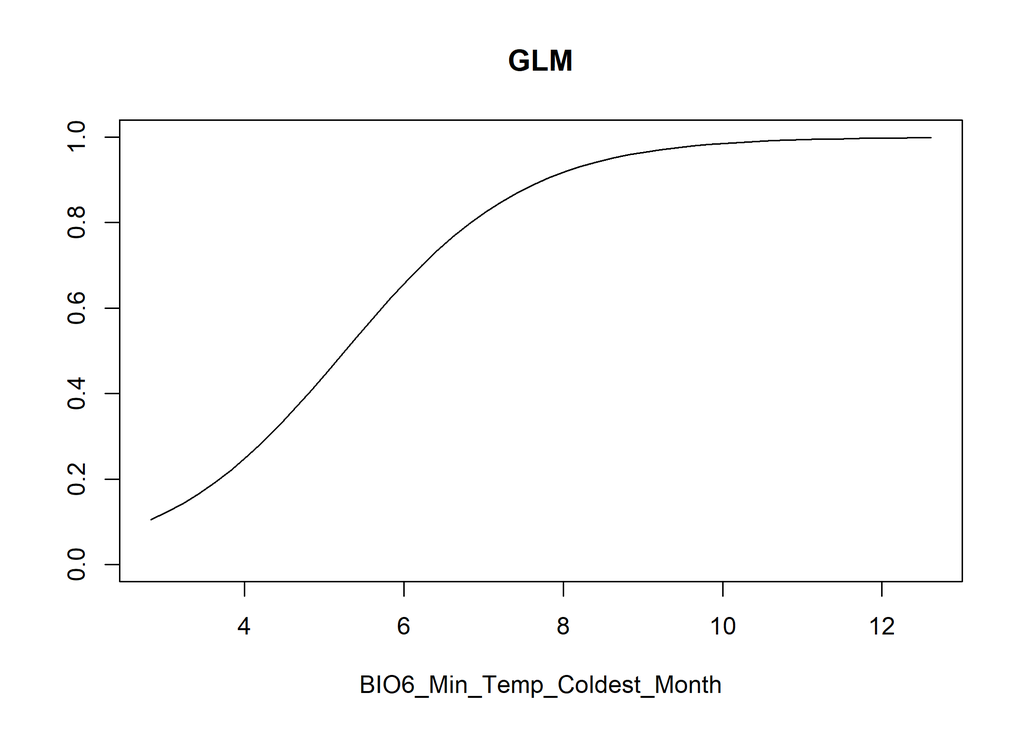

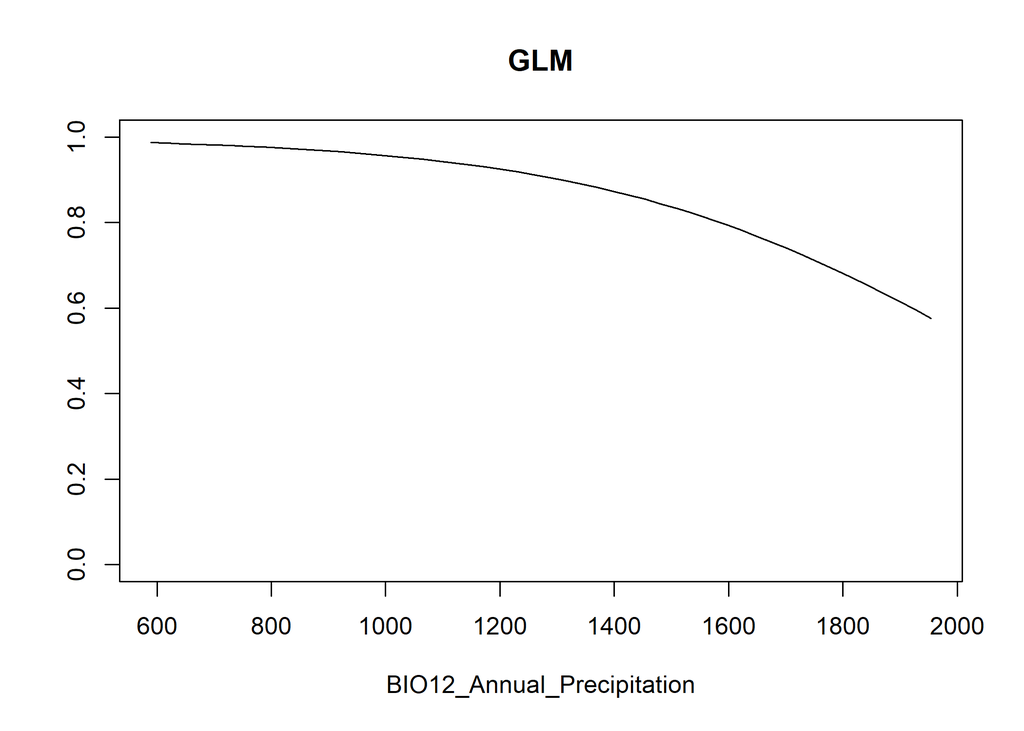

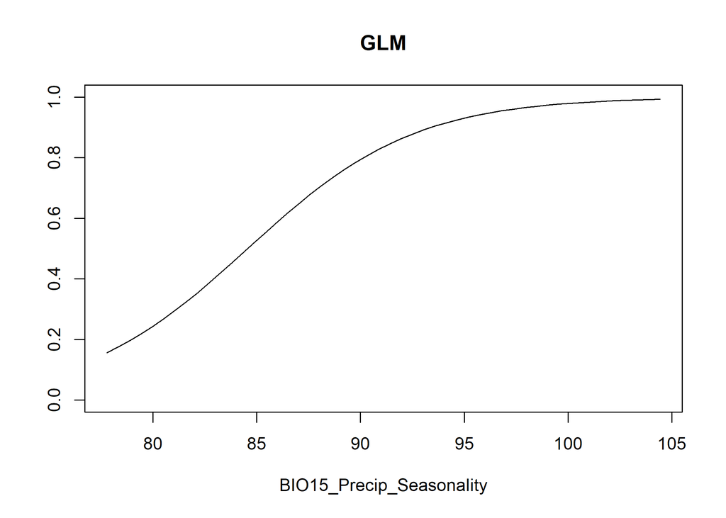

```r
# Plot the partial responses
partial_response(glm_model_1, predictors = train_PB_covs_thinned[,predictors], main='GLM')
```

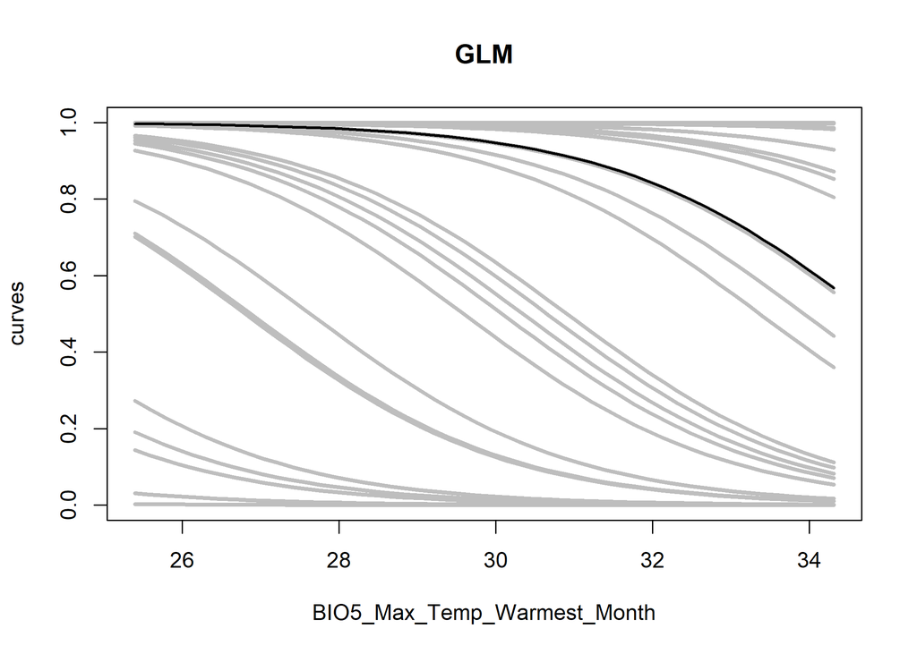

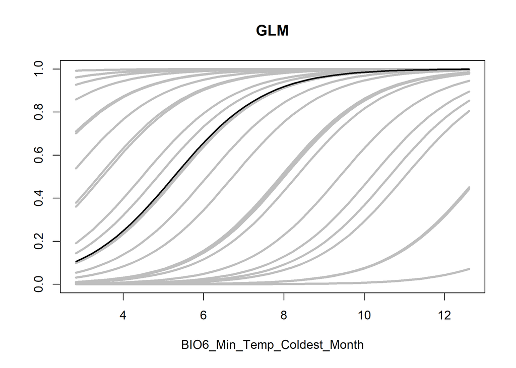

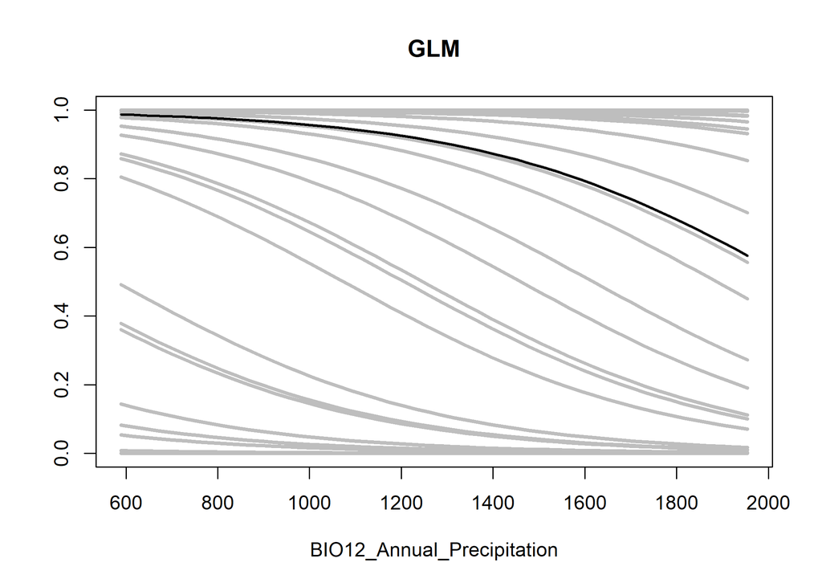

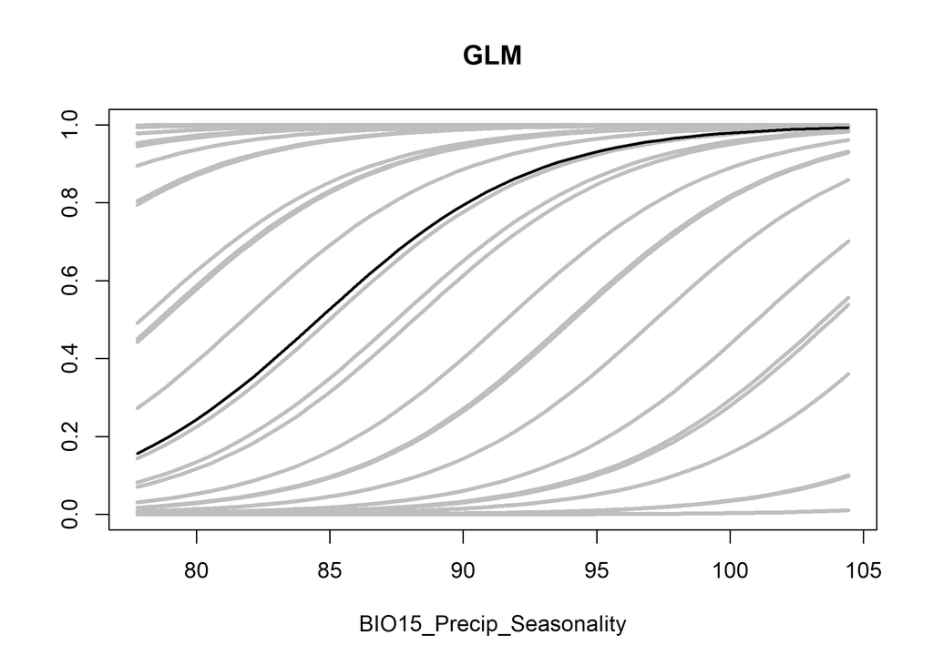

```r
# Plot inflated response curves:
inflated_response(glm_model_1, predictors = train_PB_covs_thinned[,predictors], method = "stat3", lwd = 3, main='GLM')
```

### Model 2 partial responses

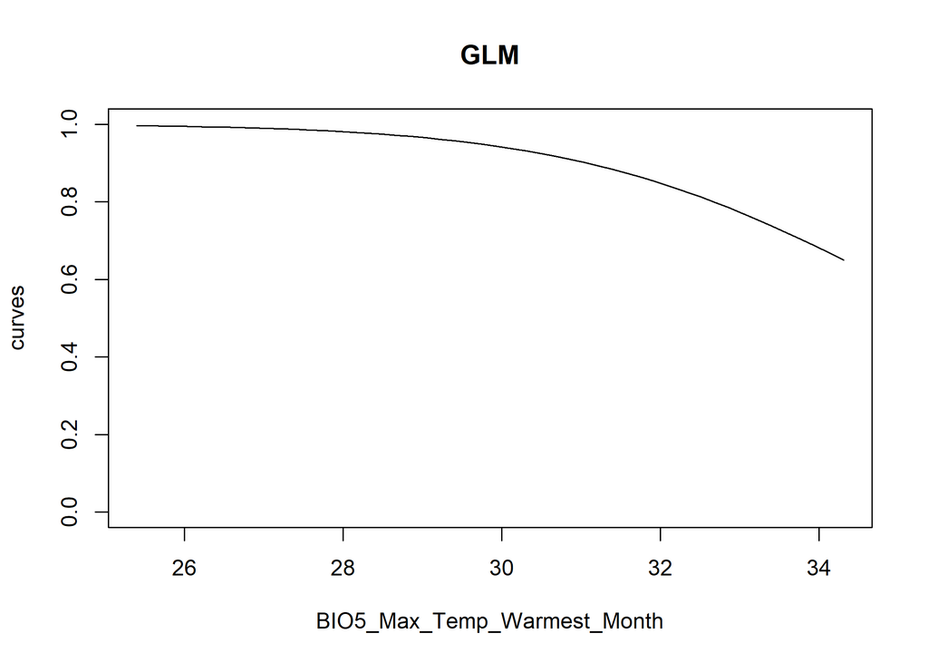

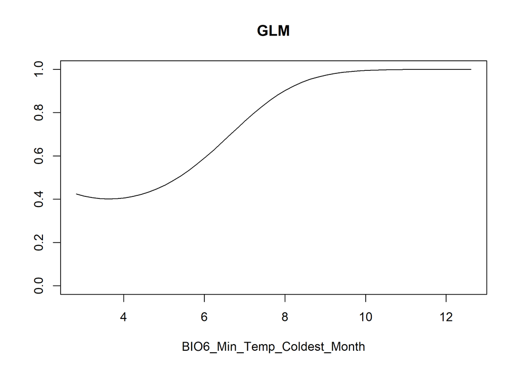

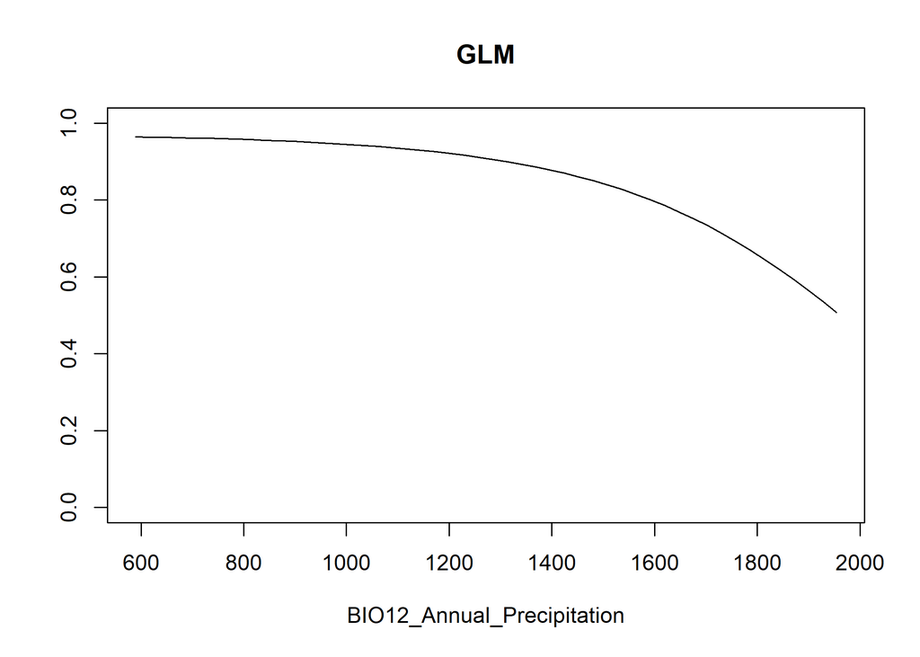

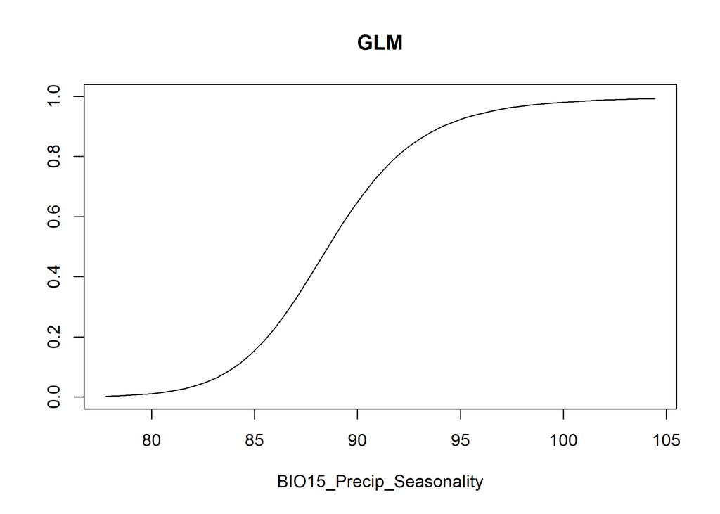

```r
# Plot the partial responses
partial_response(glm_model_2, predictors = train_PB_covs_thinned[,predictors], main='GLM')
```

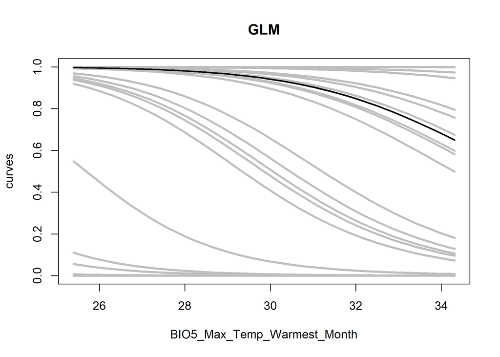

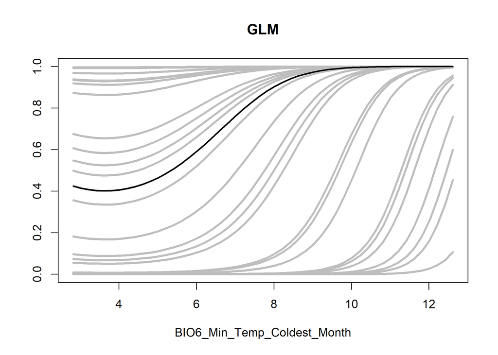

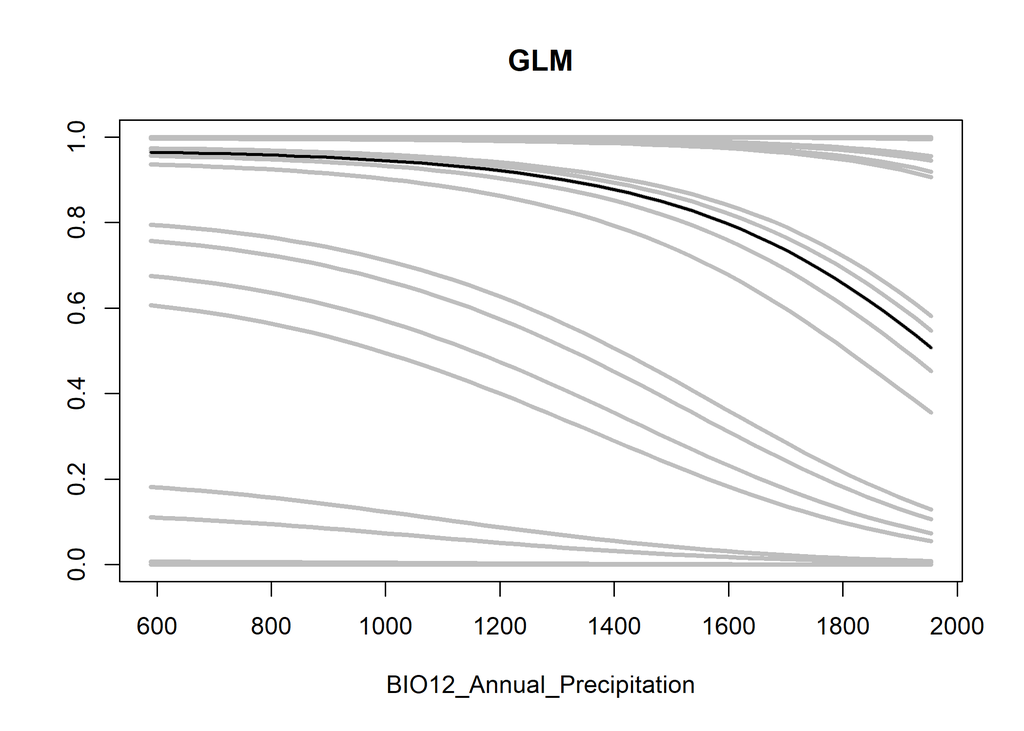

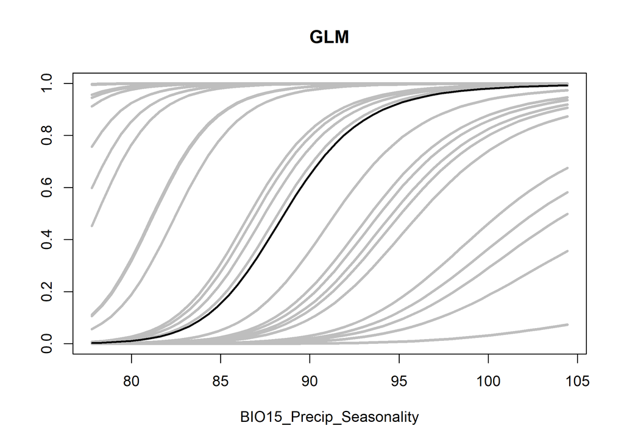

```r
# Plot inflated response curves:
inflated_response(glm_model_2, predictors = train_PB_covs_thinned[,predictors], method = "stat3", lwd = 3, main='GLM')
```

## GLM predictions to current environment

### Model 1

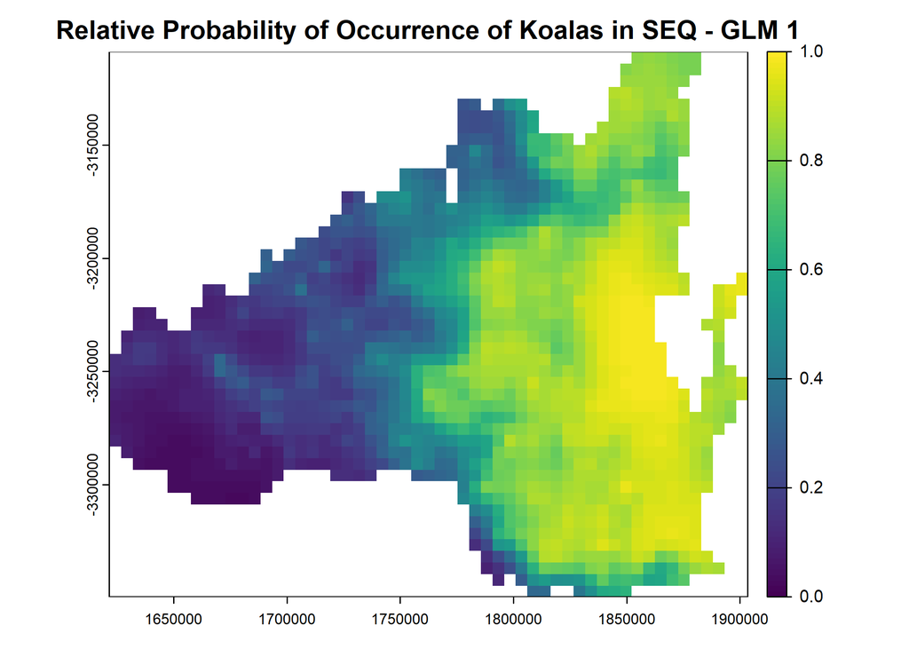

```r
# Predict the presence probability across the entire raster extent
predicted_raster_model_1 <- predicts::predict(covs_current_expert, glm_model_1, type = "response")

# Plot the species distribution raster
plot(
  predicted_raster_model_1,
  range = c(0, 1),  # Set min and max values for the color scale
  main = "Relative Probability of Occurrence of Koalas in SEQ - GLM 1"
)
```

### Model 2

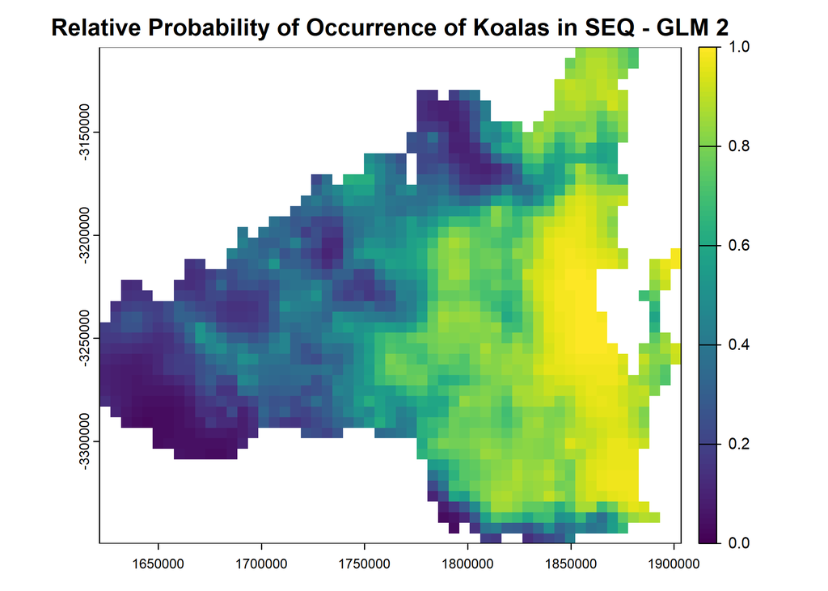

```r
# Predict the presence probability across the entire raster extent
predicted_raster_model_2 <- predicts::predict(covs_current_expert, glm_model_2, type = "response")

# Plot the species distribution raster
plot(
  predicted_raster_model_2,
  range = c(0, 1),  # Set min and max values for the color scale
  main = "Relative Probability of Occurrence of Koalas in SEQ - GLM 2"
)
```

# Random forest

```r
# Make a folder to save outputs

dir.create("Outputs/RF_outputs", showWarnings = F)
```

## Data preparation

### Calculate the case weights (down/up-weighting)

Because we have a ‘class imbalance’ (uneven number of presences and background points), we are making their ‘weight’ in the model equal.

```r
presNum <- as.numeric(table(train_PB_covs_thinned$Presence)["1"]) # number of presences
bgNum <- as.numeric(table(train_PB_covs_thinned$Presence)["0"]) # number of backgrounds
weight <- ifelse(train_PB_covs_thinned$Presence == 1, 1, presNum / bgNum) # down-weighting
```

### Prepare for fitting the RF model(s)

```r
# If wanting to fit a classification model
# Convert the response to factor for producing class relative likelihood
train_PB_covs_thinned$Presence_Factor <- as.factor(train_PB_covs_thinned$Presence)

# For down-sampling, the number of background (0s) in each bootstrap sample should the same as presences
# (1s). For this, we use sampsize argument to do this.
# We need to choose the SMALLER number out of the two classes
sample_size <- c("0" = bgNum, "1" = bgNum)
sample_size <- c(bgNum)
```

## Random Forest Model - expert covariates

### Classification or regression model?

```r
# # Specify the model formula - classification
# model_formula <- as.formula(Presence_Factor ~
#                               BIO5_Max_Temp_Warmest_Month +
#                               BIO6_Min_Temp_Coldest_Month +
#                               BIO12_Annual_Precipitation +
#                               BIO15_Precip_Seasonality)

# Specify the model formula - regression
model_formula <- as.formula(Presence ~
                              BIO5_Max_Temp_Warmest_Month +
                              BIO6_Min_Temp_Coldest_Month +
                              BIO12_Annual_Precipitation +
                              BIO15_Precip_Seasonality)
```

### Fit the random forest model

This will throw a warning as we only have two unique values (0s and 1s), but in our case that is fine, and you can ignore the warning.

```r
rf_1 <- randomForest::randomForest(formula = model_formula,
                                   data = train_PB_covs_thinned,
                                   weights = weight,
                                   ntree = 1000,
                                   sampsize = sample_size,
                                   replace = T,
                                   importance=TRUE)
```

```
Warning in randomForest.default(m, y, ...): The response has five or fewer
unique values.  Are you sure you want to do regression?
```

### Check the model results

```r
# Model summary
rf_1
```

```
Call:
 randomForest(formula = model_formula, data = train_PB_covs_thinned,      weights = weight, ntree = 1000, sampsize = sample_size, replace = T,      importance = TRUE)
               Type of random forest: regression
                     Number of trees: 1000
No. of variables tried at each split: 1

          Mean of squared residuals: 0.08464043
                    % Var explained: 24.02
```

```r
# Variable importance:
importance(rf_1)
```

```
                              %IncMSE IncNodePurity
BIO5_Max_Temp_Warmest_Month  91.42738      67.35590
BIO6_Min_Temp_Coldest_Month 112.16890     103.63237
BIO12_Annual_Precipitation   81.56532      85.42466
BIO15_Precip_Seasonality     75.60041      46.61974
```

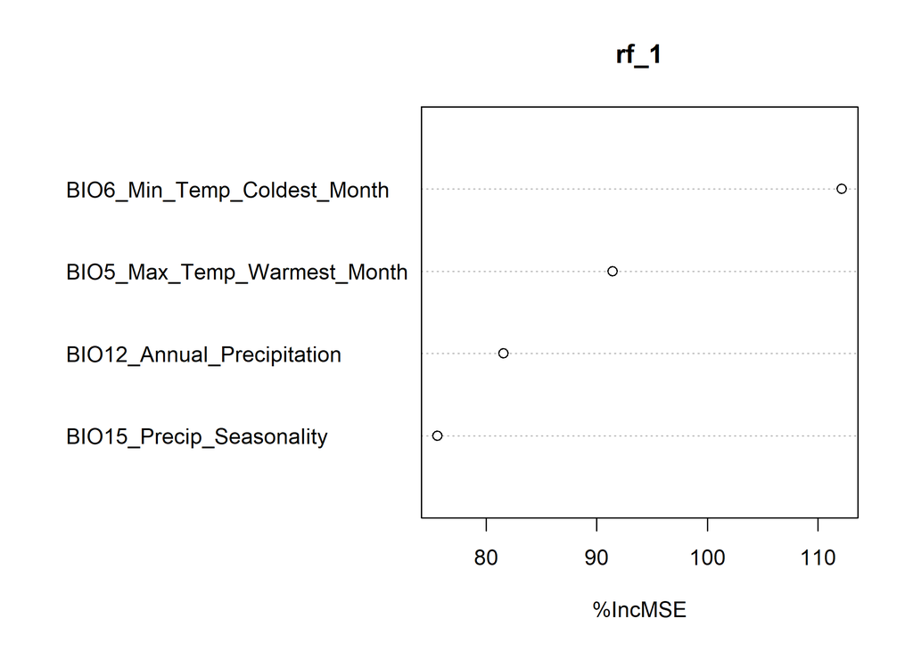

```r
# Plot variable importance
varImpPlot(rf_1, type = 1)
```

```r
# Look at single trees:
head(getTree(rf_1,1,T))
```

|  | left daughter | right daughter | split var | split point | status | prediction |
| --- | --- | --- | --- | --- | --- | --- |
| 1 | 2 | 3 | BIO6_Min_Temp_Coldest_Month | 8.303799 | -3 | 0.50478142 |
| 2 | 4 | 5 | BIO6_Min_Temp_Coldest_Month | 3.929037 | -3 | 0.23415265 |
| 3 | 6 | 7 | BIO12_Annual_Precipitation | 1280.524536 | -3 | 0.80752533 |
| 4 | 8 | 9 | BIO12_Annual_Precipitation | 653.222107 | -3 | 0.03846154 |
| 5 | 10 | 11 | BIO6_Min_Temp_Coldest_Month | 7.116694 | -3 | 0.33333333 |
| 6 | 12 | 13 | BIO6_Min_Temp_Coldest_Month | 10.093417 | -3 | 0.93777778 |

### Partial dependence plots

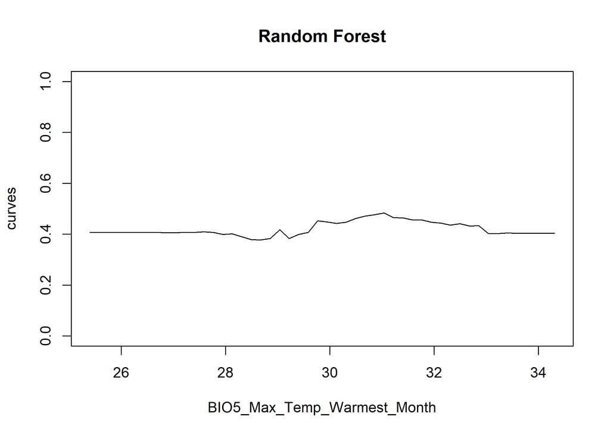

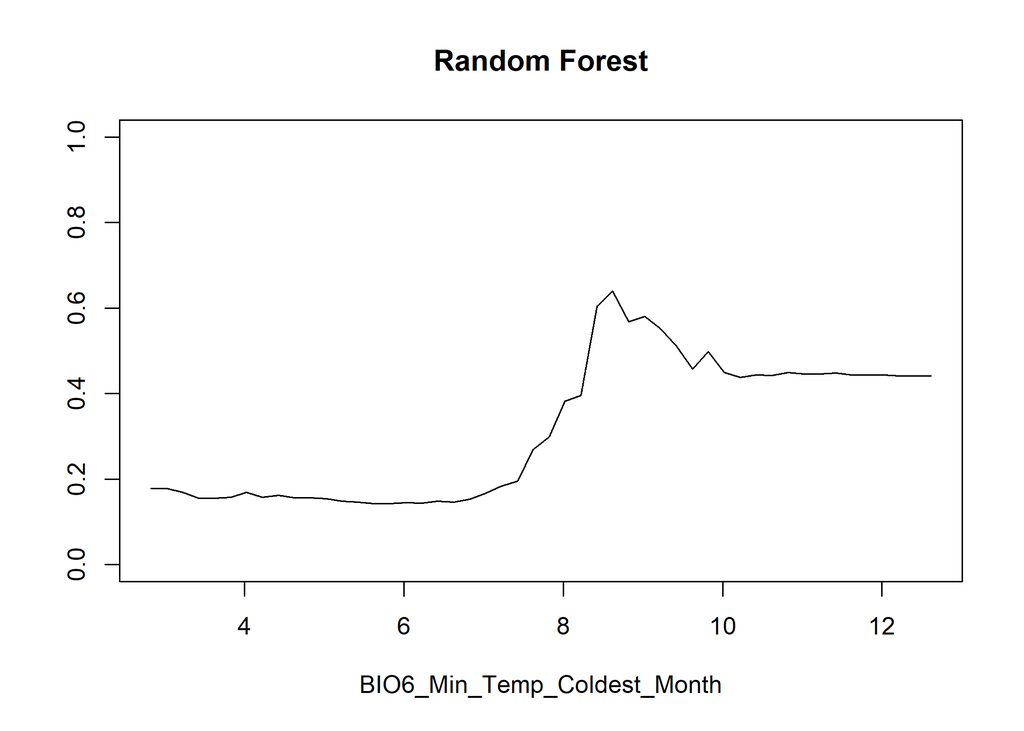

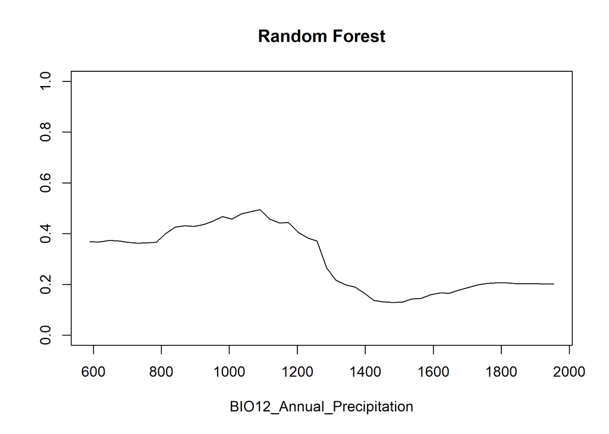

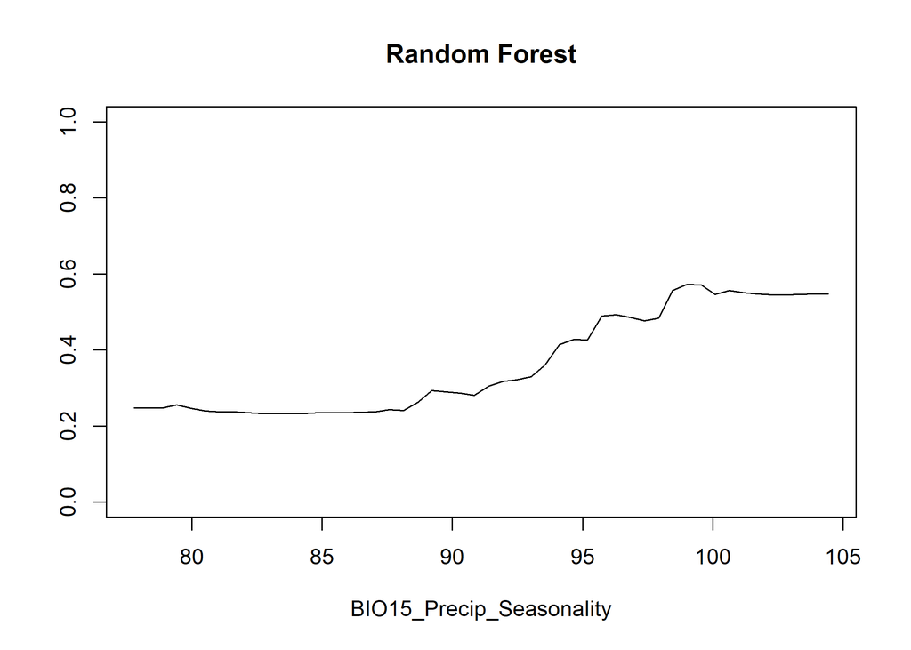

```r
# Now, we plot response curves in the same way as we did for GLMs above:
partial_response(rf_1, predictors = train_PB_covs_thinned[,predictors], main='Random Forest')
```

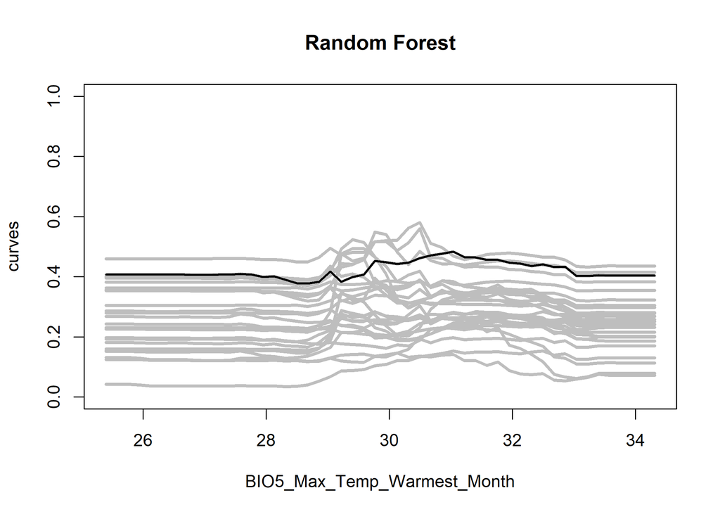

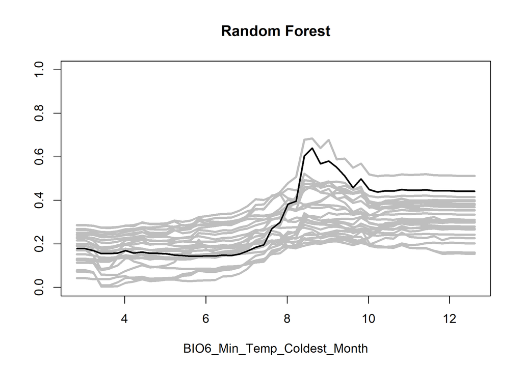

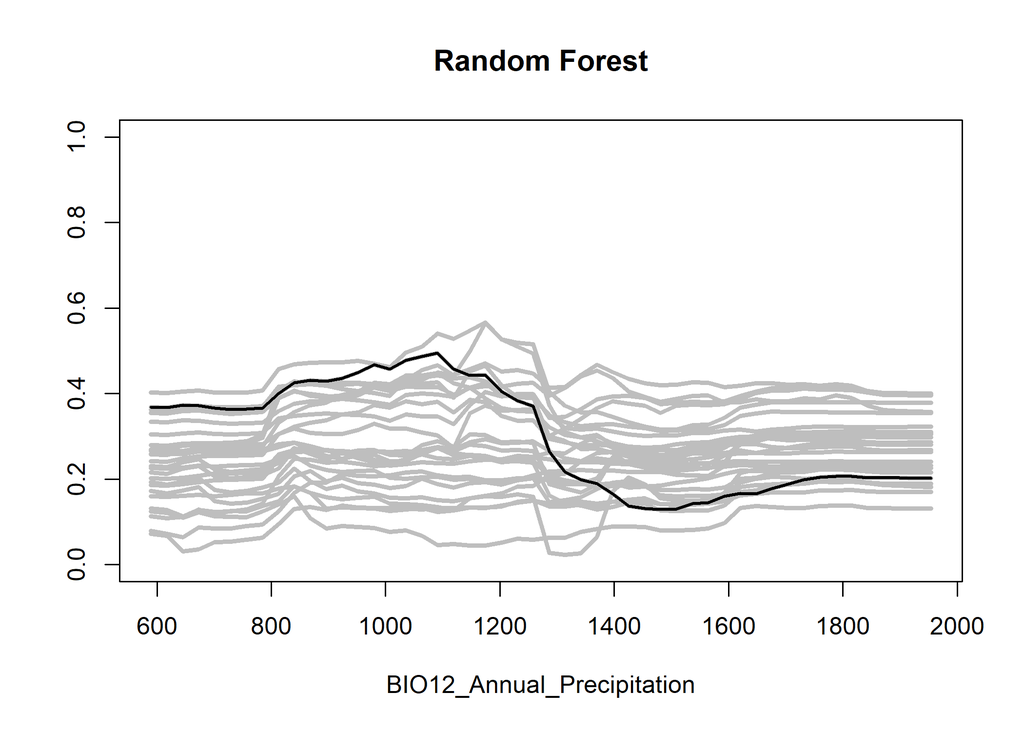

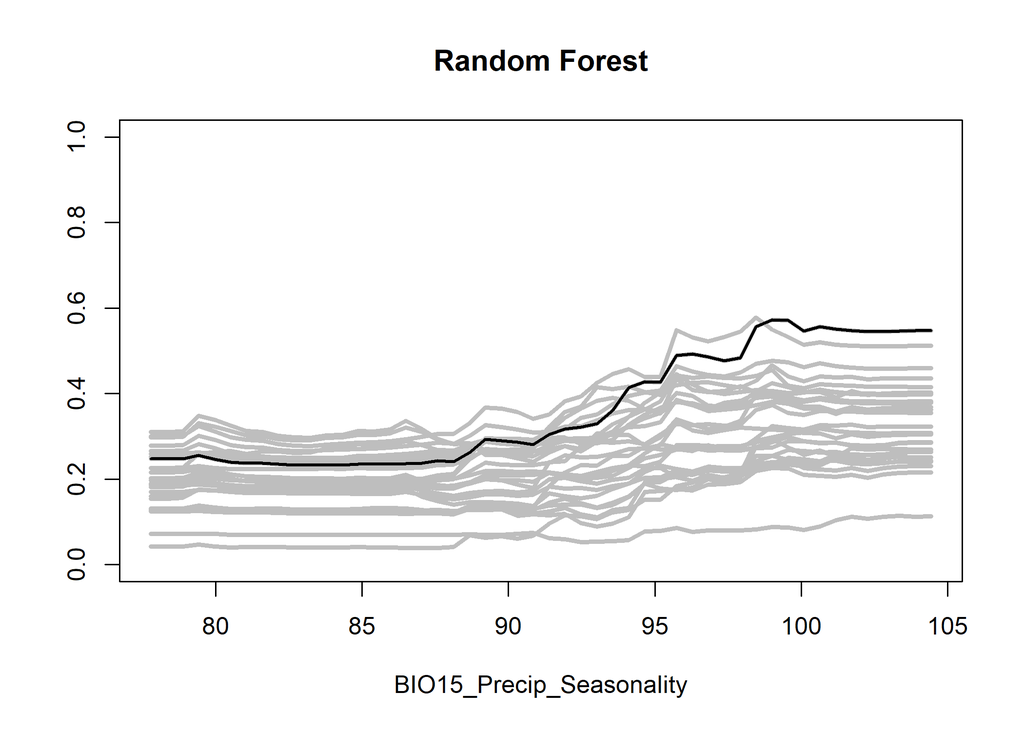

```r
# Plot inflated response curves:
inflated_response(rf_1, predictors = train_PB_covs_thinned[,predictors], method = "stat3", lwd = 3, main='Random Forest')
```

### Random Forest predictions

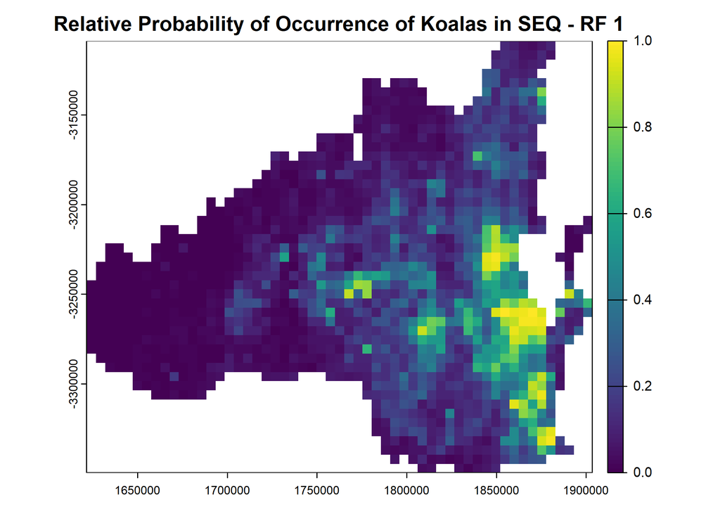

```r
# Predict the presence probability across the entire raster extent
predicted_raster_RF_1 <- predicts::predict(covs_current_expert, rf_1, type = "response")

# Plot the species distribution raster
plot(
  predicted_raster_RF_1,
  range = c(0, 1),  # Set min and max values for the color scale
  main = "Relative Probability of Occurrence of Koalas in SEQ - RF 1"
)
```

# Model evaluation with spatial block cross-validation

```
  train_0 train_1 test_0 test_1
1    1185    9043    279    957
2    1187    8317    277   1683
3    1176    9185    288    815
4    1177    8352    287   1648
5    1131    5103    333   4897
```

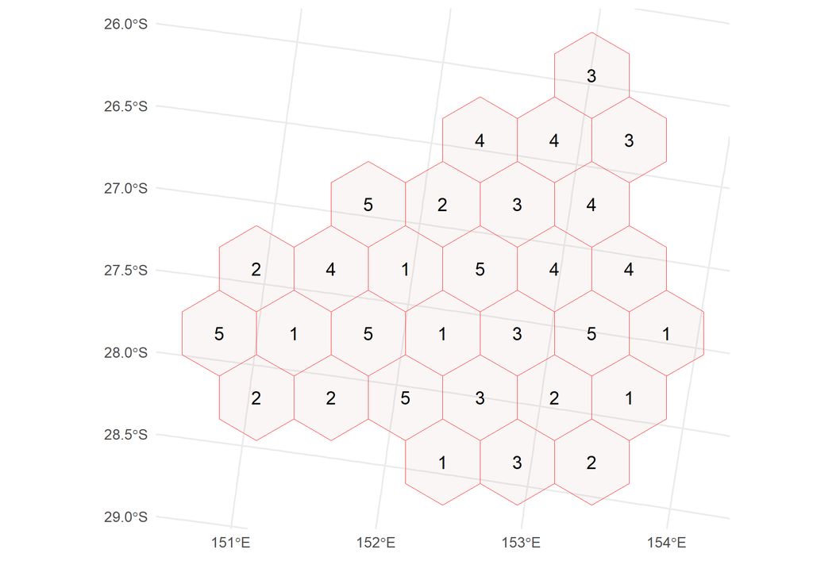

```r
# Convert training data to sf
train_PB_covs_thinned_sf <- st_as_sf(train_PB_covs_thinned[, c("x", "y", "Presence")], coords = c("x", "y"), crs = "EPSG:3112")

# Generate spatial blocks
spblock <- cv_spatial(x = train_PB_covs_thinned_sf,
                      column = "Presence",
                      r = NULL,
                      size = 50000, # Size of the blocks in metres
                      k = 5,
                      hexagon = TRUE,
                      selection = "random",
                      iteration = 100, # to find evenly-dispersed folds
                      biomod2 = FALSE)
```

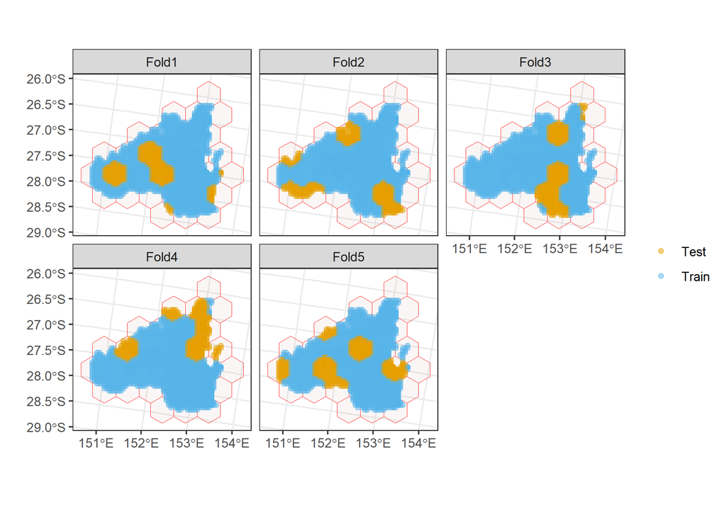

```r
cv_plot(cv = spblock,
        x = train_PB_covs_thinned_sf,
        points_alpha = 0.5,
        nrow = 2)
```

```r
# Extract the folds to save
spfolds <- spblock$folds_list

# We now have a list of 5 folds, where the first object is the training data, and the second is the testing data
str(spfolds)
```

```
List of 5
 $ :List of 2
  ..$ : int [1:10228] 10859 10657 10911 10860 10753 10806 10912 10804 10805 11020 ...
  ..$ : int [1:1236] 10667 11031 10666 10816 10766 10767 10713 10714 10758 10716 ...
 $ :List of 2
  ..$ : int [1:9504] 10859 10657 10911 10860 10753 10806 10912 10804 10805 11020 ...
  ..$ : int [1:1960] 11263 11226 11225 11129 11128 11223 11264 11267 11022 11075 ...
 $ :List of 2
  ..$ : int [1:10361] 10859 10657 10911 10860 10753 10806 10912 10804 10805 11020 ...
  ..$ : int [1:1103] 6493 2803 2195 11249 5437 5068 11305 2966 11308 11385 ...
 $ :List of 2
  ..$ : int [1:9529] 10859 10657 10911 10860 10753 10806 10912 10804 10805 11020 ...
  ..$ : int [1:1935] 10530 10571 10619 10575 10327 10330 10574 10579 10532 3891 ...
 $ :List of 2
  ..$ : int [1:6234] 11263 11226 11225 11129 11128 11223 11264 11267 11022 11075 ...
  ..$ : int [1:5230] 10859 10657 10911 10860 10753 10806 10912 10804 10805 11020 ...
```

## Run the model for every fold and evaluate

### Model evaluation - metrics

Typically, it helps to evaluate your model with several metrics that describe different features of model performance and prediction. Here, we define a function to feed in a model prediction and calculate several evaluation metrics.

The metrics are:

-Area under the receiver operating characteristic curve (AUC ROC)

Higher values of this (closer to 1) suggest a model is good at distinguishing presence points from the background.

-Continuous boyce index

Higher values of this (closer to 1) suggest a model is good at predicting higher suitability at spots where there were presences.

```r
# Start a dataframe to save results
eval_df <- data.frame(fold = numeric(),
                      ROC = numeric(),
                      boyce = numeric())

for(f in seq_along(spfolds)) {

  # Subset the training and testing data (spatial cross validation) (for the fth fold)

  train_PB_covs_scv <- train_PB_covs_thinned[spfolds[[f]][[1]], ]
  test_PB_covs_scv <- train_PB_covs_thinned[spfolds[[f]][[2]], ]

  glm_model_1 <- glm(Presence ~
                     BIO5_Max_Temp_Warmest_Month +
                     BIO6_Min_Temp_Coldest_Month +
                     BIO12_Annual_Precipitation +
                     BIO15_Precip_Seasonality,
                   data=train_PB_covs_scv,
                   family = binomial(link = "logit"))

    # Predict to the testing data of fold f
  test_PB_covs_scv$pred <- predict(glm_model_1, newdata = test_PB_covs_scv, type = "response")

  # Evaluate prediction on test set
  ROC = precrec::auc(precrec::evalmod(scores = test_PB_covs_scv$pred, labels = test_PB_covs_scv$Presence))[1,4]

  boyce = ecospat::ecospat.boyce(fit = test_PB_covs_scv$pred,
                                 obs = test_PB_covs_scv$pred[which(test_PB_covs_scv$Presence==1)],
                                 nclass = 0, # Calculate continuous index
                                 method = "pearson",
                                 PEplot = F)[["cor"]]

  # Add results to dataframe
  eval_df <- eval_df %>% add_row(fold = f, ROC = ROC, boyce = boyce)


}
```

### Summarise the evaluation metrics

```r
# Mean AUC & boyce
eval_df %>%
  summarise(mean_AUC = mean(ROC),
            mean_boyce = mean(boyce),
            sd_AUC = sd(ROC),
            sd_boyce = sd(boyce))
```

| mean_AUC | mean_boyce | sd_AUC | sd_boyce |
| --- | --- | --- | --- |
| 0.8155711 | 0.8022 | 0.1135331 | 0.1875612 |

# Model evaluation for Random Forest with spatial block cross-validation

We’re going to use the same spatial folds as before.

## Run the RF model for every fold and evaluate

```r
# Start a dataframe to save results
eval_df.RF <- data.frame(fold = numeric(),
                      ROC = numeric(),
                      boyce = numeric())

for(f in seq_along(spfolds)) {

  # Subset the training and testing data (spatial cross validation) (for the fth fold)

  train_PB_covs_scv <- train_PB_covs_thinned[spfolds[[f]][[1]], ]
  test_PB_covs_scv <- train_PB_covs_thinned[spfolds[[f]][[2]], ]

  presNum <- as.numeric(table(train_PB_covs_scv$Presence)["1"]) # number of presences
  bgNum <- as.numeric(table(train_PB_covs_scv$Presence)["0"]) # number of backgrounds
  weight <- ifelse(train_PB_covs_scv$Presence == 1, 1, presNum / bgNum) # down-weighting

  sample_size <- c("0" = bgNum, "1" = bgNum)
  sample_size <- c(bgNum)


  rf_1 <- randomForest::randomForest(formula = model_formula,
                                   data = train_PB_covs_scv,
                                   weights = weight,
                                   ntree = 1000,
                                   sampsize = sample_size,
                                   replace = T,
                                   importance=TRUE)


    # Predict to the testing data of fold f
  test_PB_covs_scv$pred <- predict(rf_1, newdata = test_PB_covs_scv, type = "response")

  # Evaluate prediction on test set
  ROC = precrec::auc(precrec::evalmod(scores = test_PB_covs_scv$pred, labels = test_PB_covs_scv$Presence))[1,4]

  boyce = ecospat::ecospat.boyce(fit = test_PB_covs_scv$pred,
                                 obs = test_PB_covs_scv$pred[which(test_PB_covs_scv$Presence==1)],
                                 nclass = 0, # Calculate continuous index
                                 method = "pearson",
                                 PEplot = F)[["cor"]]

  # Add results to dataframe
  eval_df.RF <- eval_df.RF %>% add_row(fold = f, ROC = ROC, boyce = boyce)


}
```

## Summarise the evaluation metrics

```r
# Mean AUC & boyce
eval_df.RF %>%
  summarise(mean_AUC = mean(ROC),
            mean_boyce = mean(boyce),
            sd_AUC = sd(ROC),
            sd_boyce = sd(boyce))
```

| mean_AUC | mean_boyce | sd_AUC | sd_boyce |
| --- | --- | --- | --- |
| 0.7994163 | 0.739 | 0.1040664 | 0.1606207 |

# Make predictions to future climates

## Load future environmental data

```r
covs_future <- rast("Data/Environmental_variables/future_bioclim.2090.SSP370.tif")
names(covs_future) <- layer_names
covs_future
```

```
class       : SpatRaster
dimensions  : 47, 55, 19  (nrow, ncol, nlyr)
resolution  : 5123.954, 5123.954  (x, y)
extent      : 1621552, 1903370, -3349594, -3108768  (xmin, xmax, ymin, ymax)
coord. ref. : GDA94 / Geoscience Australia Lambert (EPSG:3112)
source      : future_bioclim.2090.SSP370.tif
names       : BIO1_~_Temp, BIO2_~Range, BIO3_~ality, BIO4_~ality, BIO5_~Month, BIO6_~Month, ...
min values  :   0.8177757,   0.3121004,    1.564732,    12.43535,    1.130271,   0.4521889, ...
max values  :  24.5521488,  14.5486765,   50.989292,   528.63293,   37.389927,  15.7586107, ...
```

```r
covs_future <- terra::mask(covs_future, covs_current) # Crop to SEQ extent

covs_future_expert <- subset(covs_future, names(covs_future) %in% c("BIO5_Max_Temp_Warmest_Month",
                                                                    "BIO6_Min_Temp_Coldest_Month",
                                                                    "BIO12_Annual_Precipitation",
                                                                    "BIO15_Precip_Seasonality"))
```

## Plot the future rasters

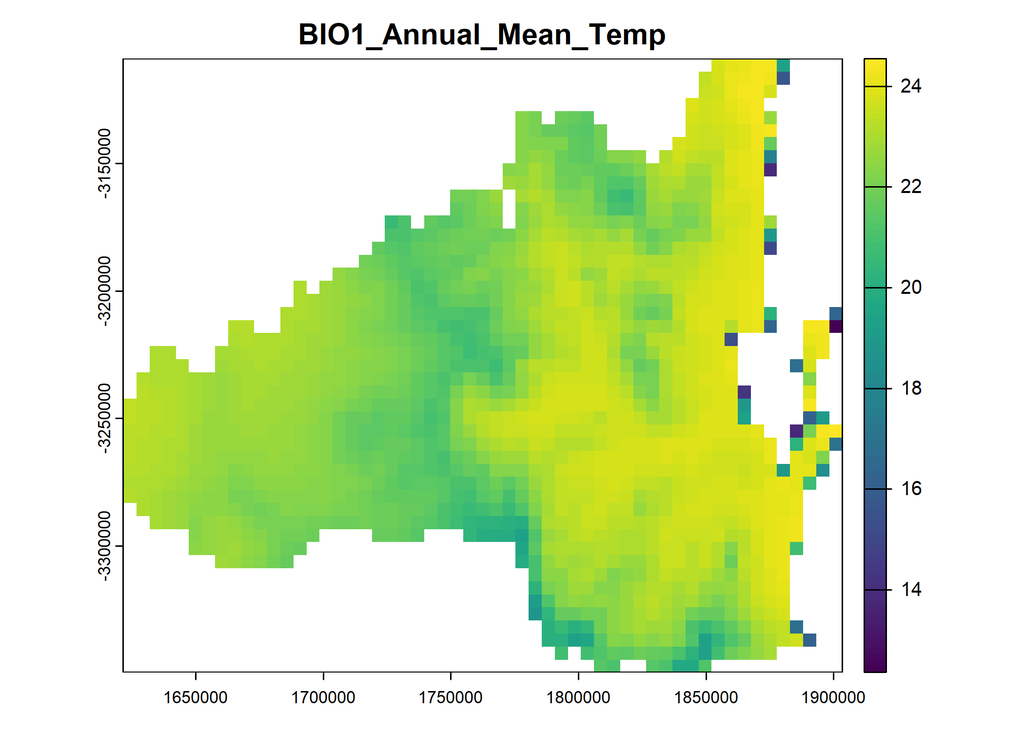

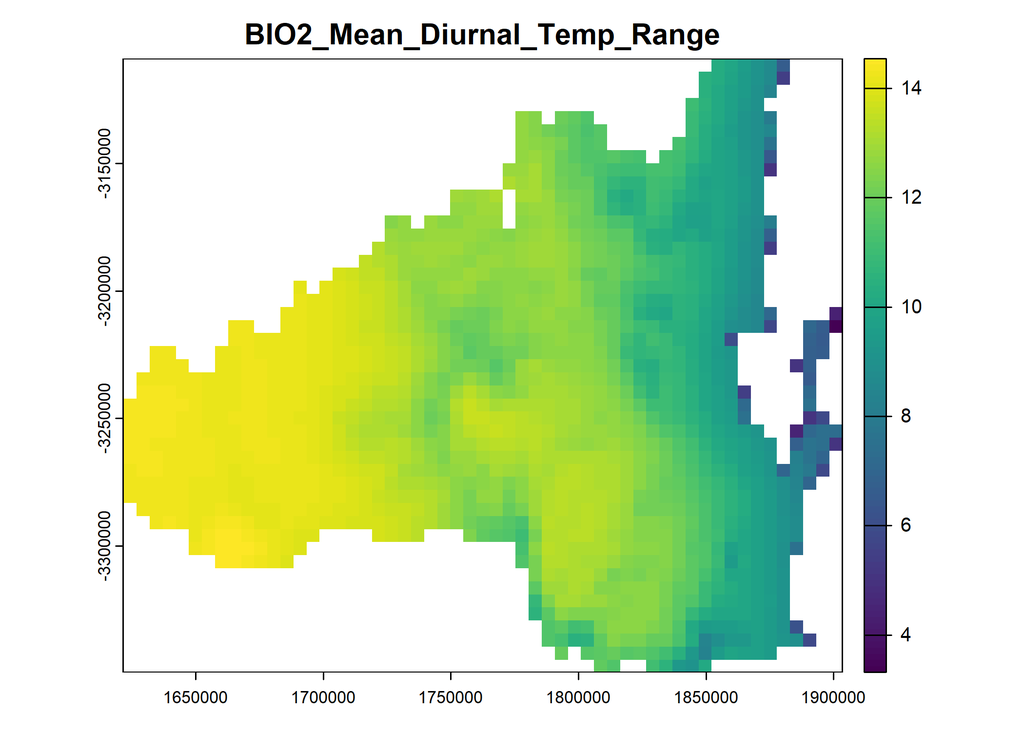

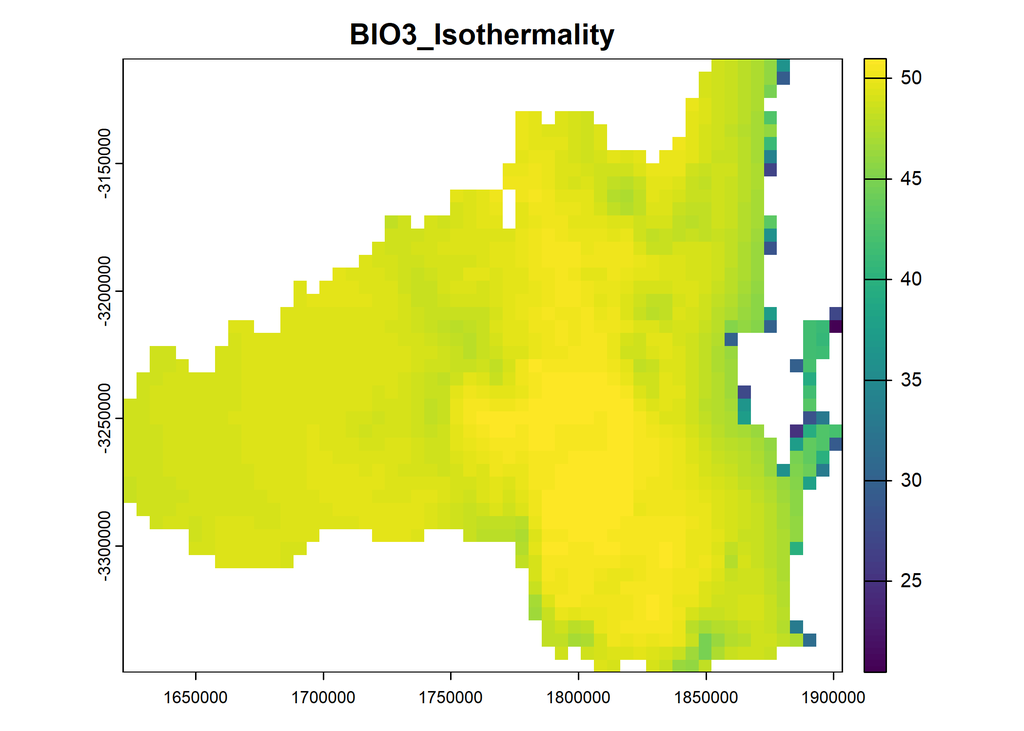

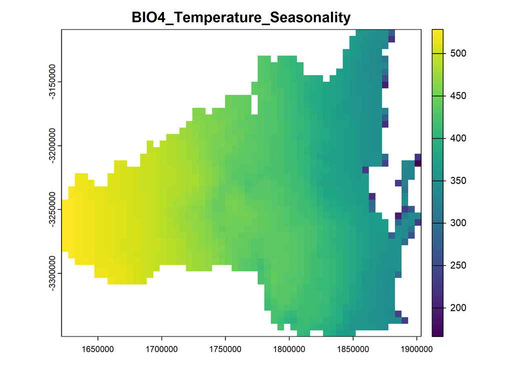

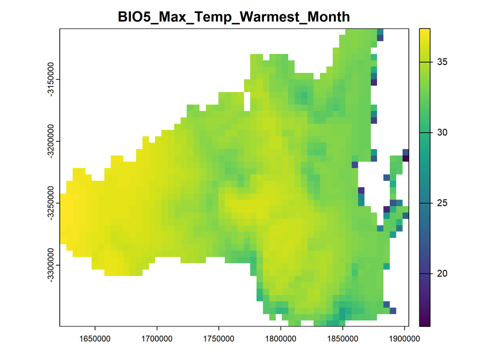

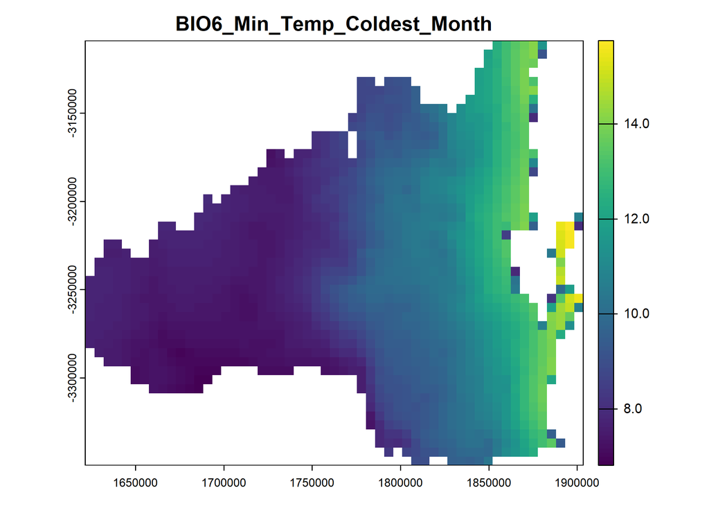

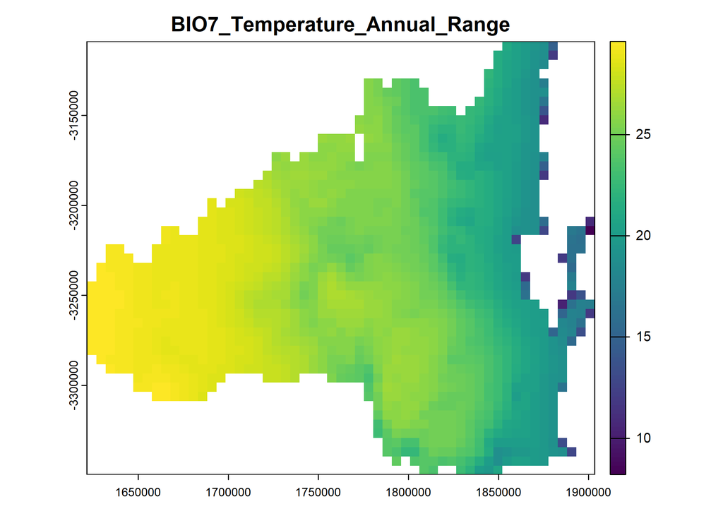

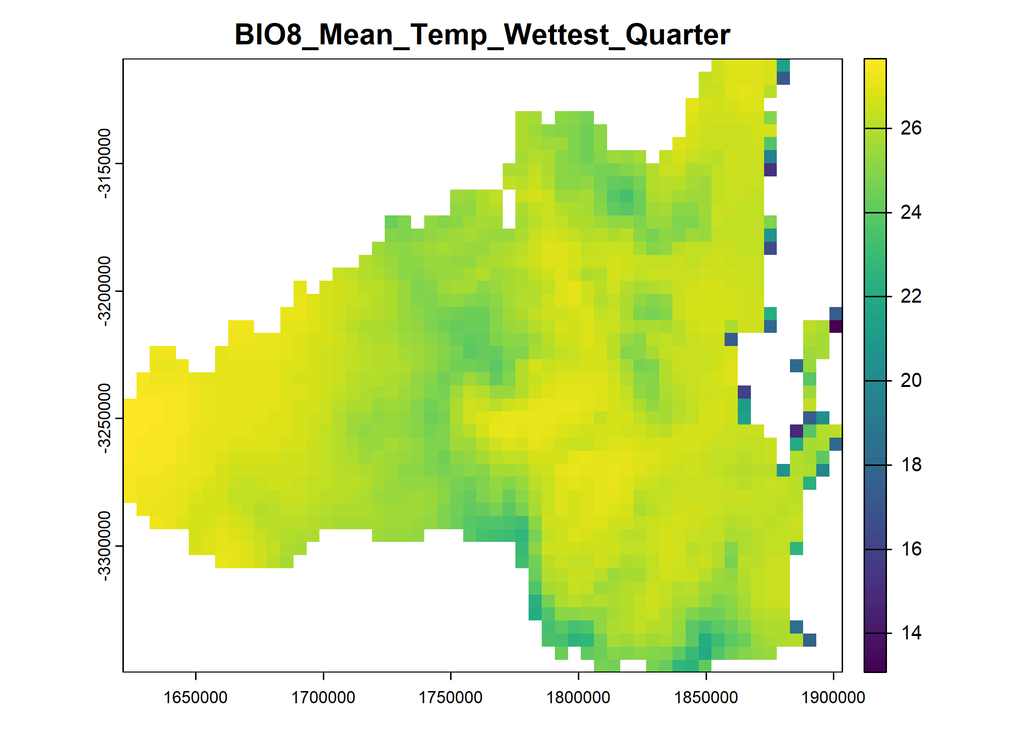

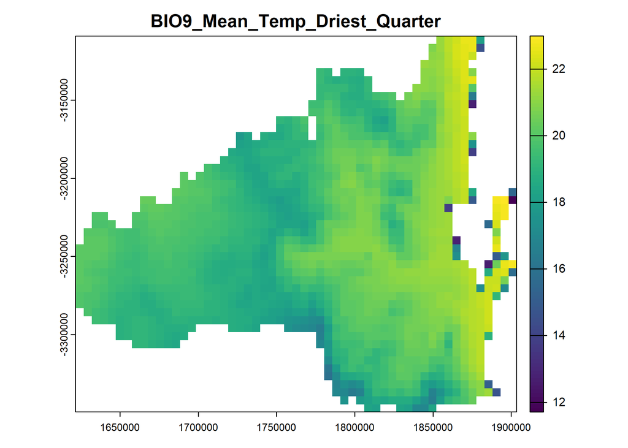

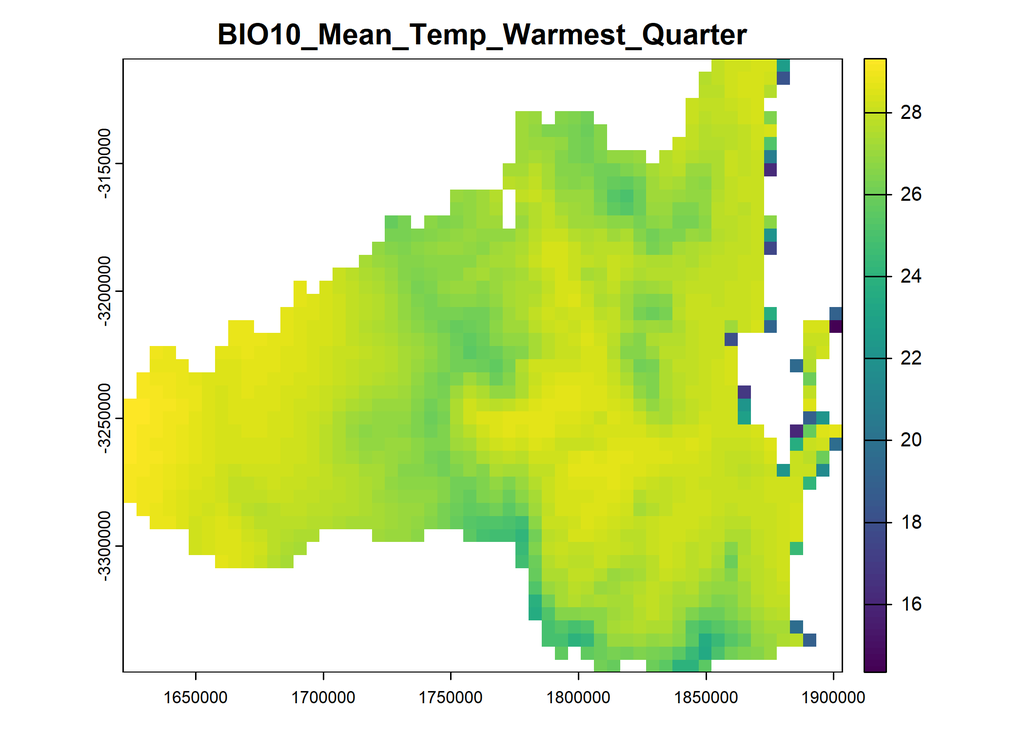

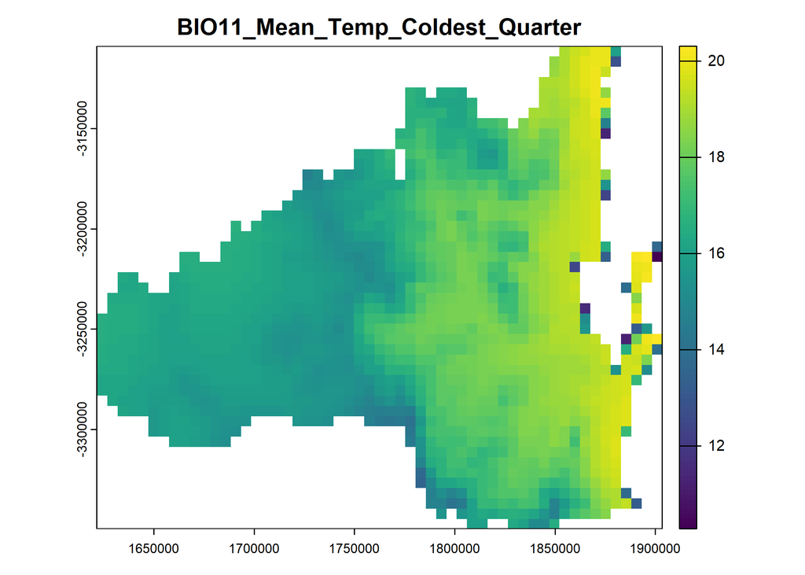

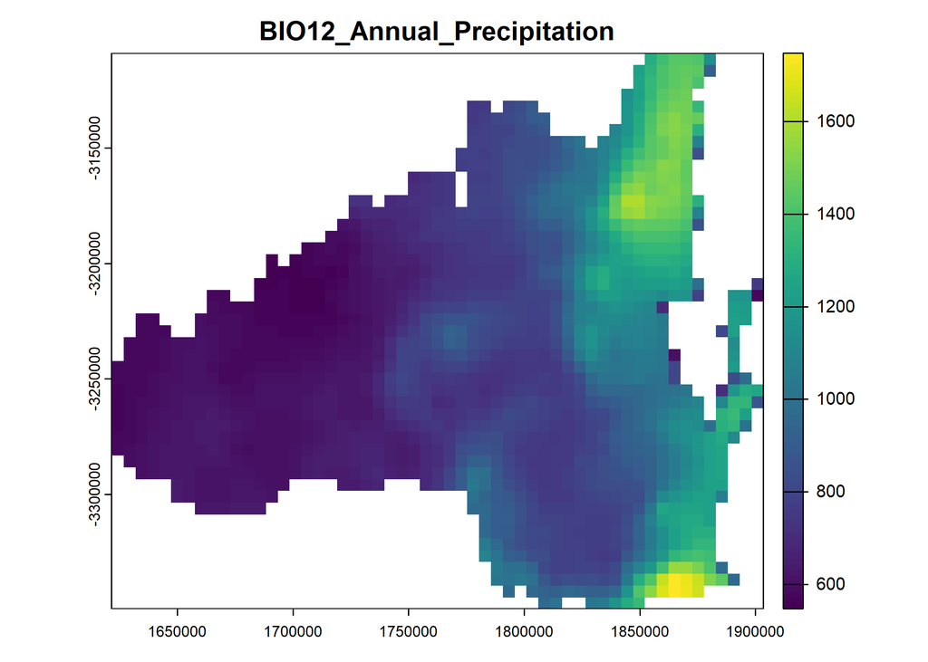

[7 more figures not shown]

```r
for(i in 1:nlyr(covs_future)) {
  terra::plot(covs_future[[i]], main = names(covs_future)[[i]])
}
```

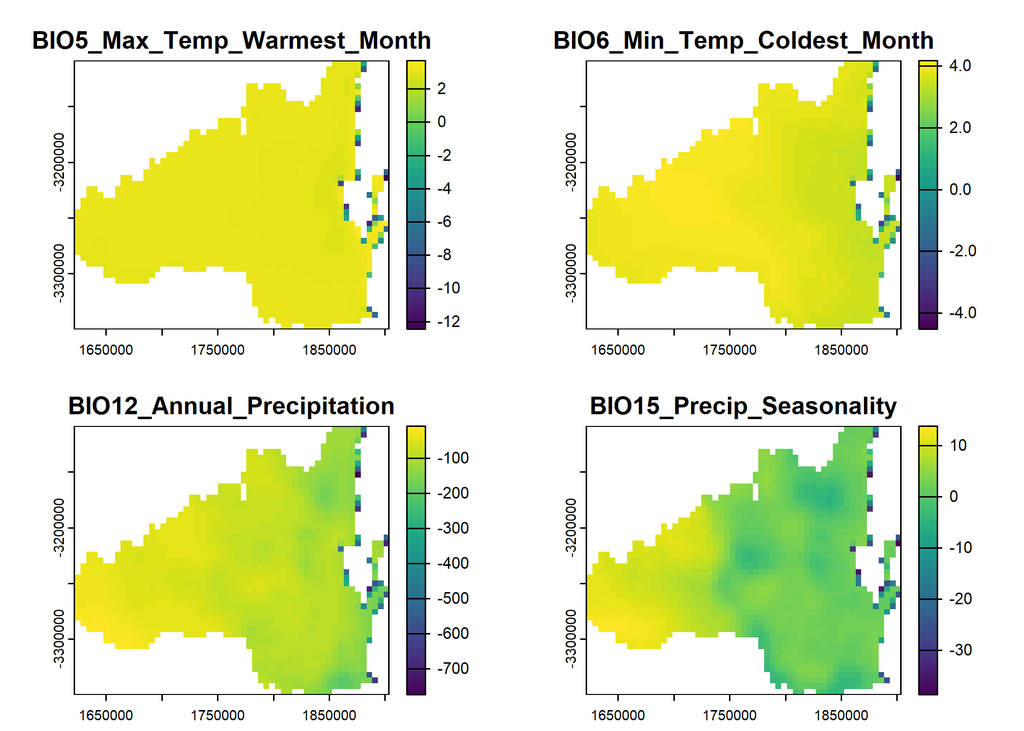

```r
# Plot to compare the difference between the current and future rasters

plot(covs_future_expert - covs_current_expert)
```

## Test the environmental distance between current data and future conditions

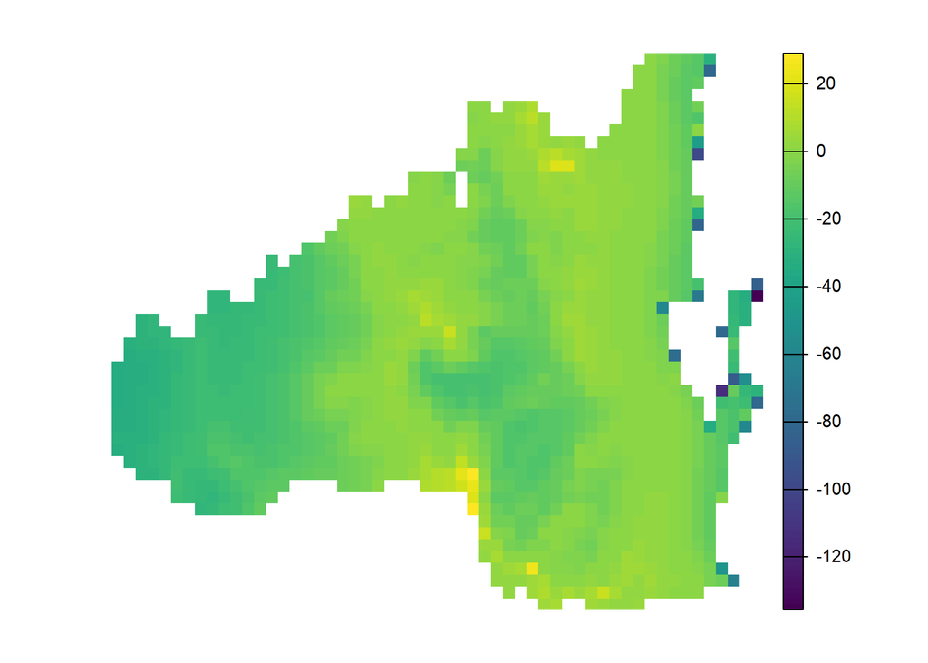

```r
mess <- predicts::mess(covs_future_expert,
                       train_PB_covs_thinned[, c("BIO5_Max_Temp_Warmest_Month",
                                            "BIO6_Min_Temp_Coldest_Month",
                                            "BIO12_Annual_Precipitation",
                                            "BIO15_Precip_Seasonality")])

plot(mess, axes = F)
```

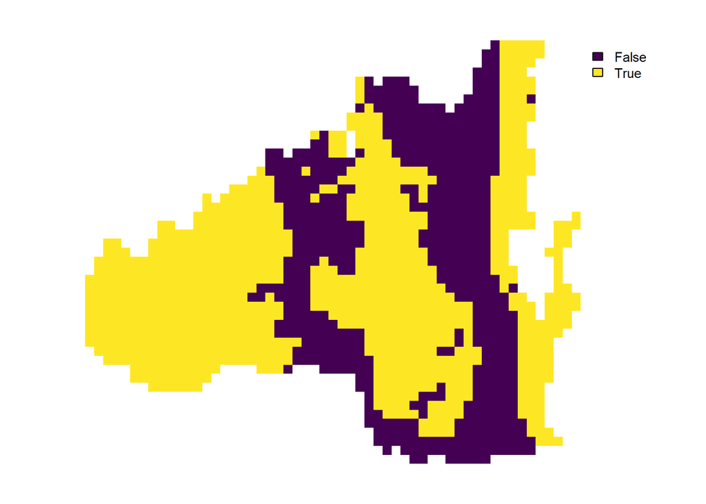

```r
r_mess_mask <- mess < 0
plot(r_mess_mask, axes=F)
```

Test which areas you might mask out because they are ‘novel’ in environmental space and therefore require model extrapolation.

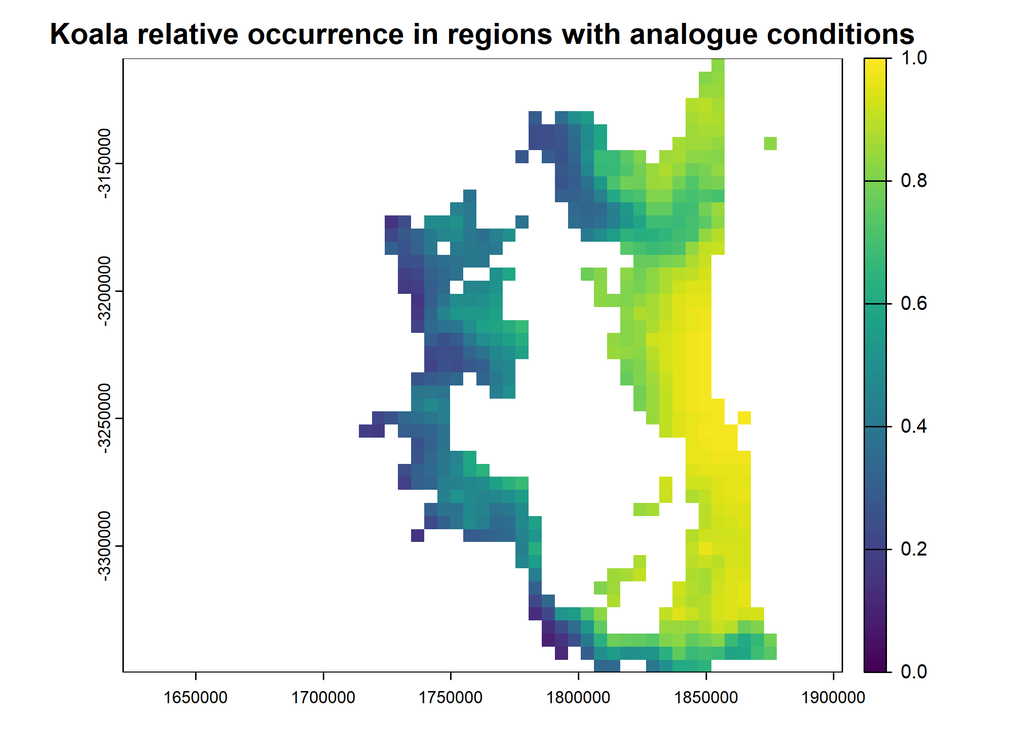

```r
analog_fut <- predicted_raster_model_1

values(analog_fut)[values(mess)<0] <- NA

plot(analog_fut,
     range = c(0, 1),  # Set min and max values for the color scale
     main = "Koala relative occurrence in regions with analogue conditions")
```

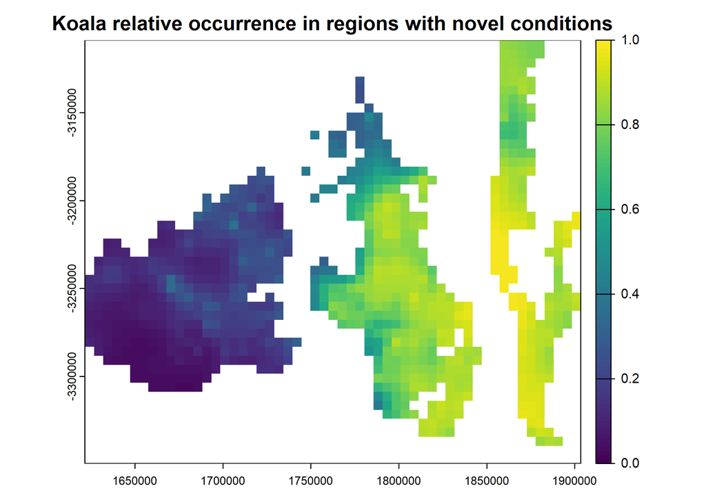

```r
novel_fut <- predicted_raster_model_1

values(novel_fut)[values(mess)>0] <- NA

plot(novel_fut,
     range = c(0, 1),  # Set min and max values for the color scale
     main = "Koala relative occurrence in regions with novel conditions")
```

# GLM future predictions

## Model 1

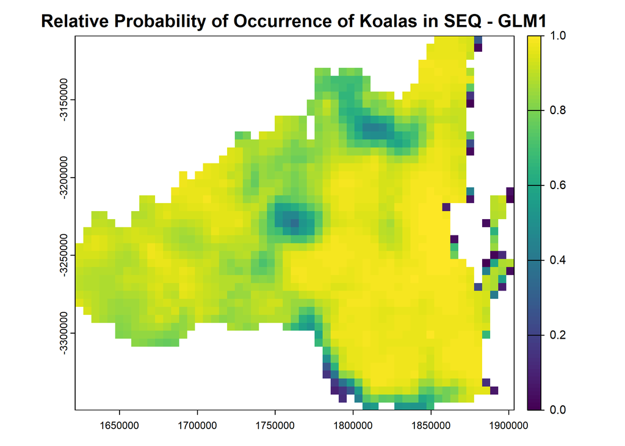

```r
# Predict the presence probability across the entire raster extent
predicted_raster_model_1 <- predict(covs_future_expert, glm_model_1, type = "response")

# Plot the species distribution raster
plot(
  predicted_raster_model_1,
  range = c(0, 1),  # Set min and max values for the color scale
  main = "Relative Probability of Occurrence of Koalas in SEQ - GLM1"
)
```

## Model 2

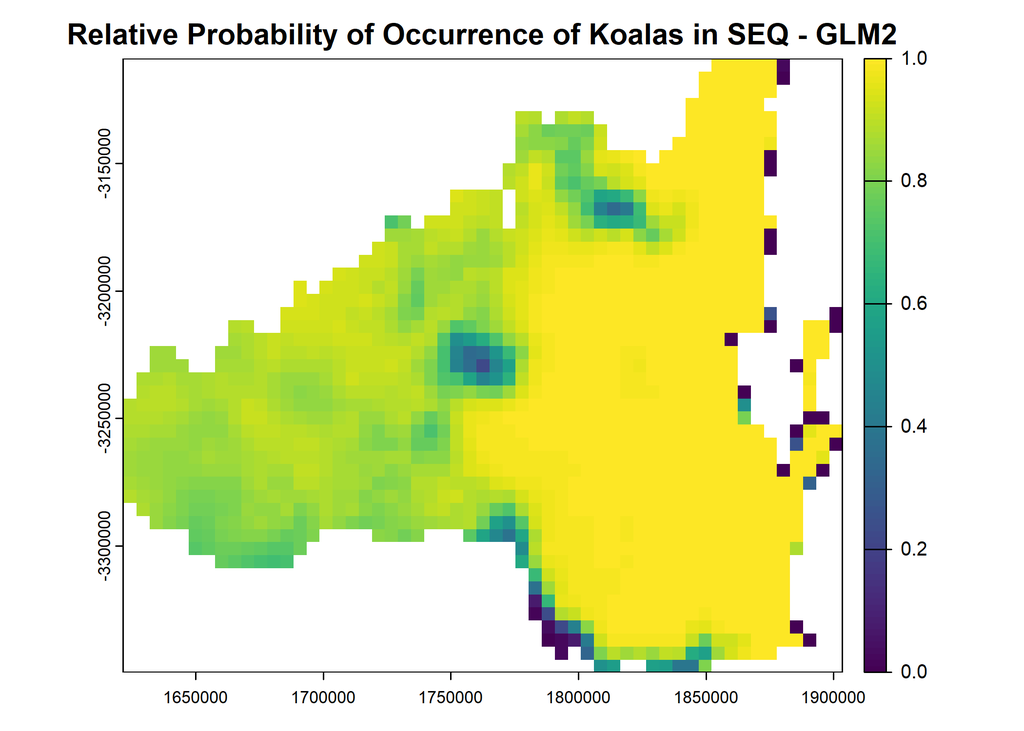

```r
# Predict the presence probability across the entire raster extent
predicted_raster_model_2 <- predict(covs_future_expert, glm_model_2, type = "response")

# Plot the species distribution raster
plot(
  predicted_raster_model_2,
  range = c(0, 1),  # Set min and max values for the color scale
  main = "Relative Probability of Occurrence of Koalas in SEQ - GLM2"
)
```

## Random Forest future predictions

### Model 1

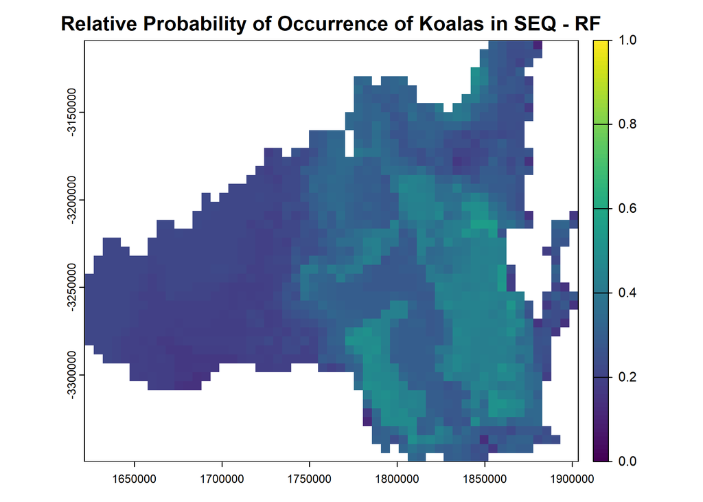

```r
# Predict the presence probability across the entire raster extent
predicted_raster_RF_1 <- predicts::predict(covs_future_expert, rf_1, type = "response", na.rm=TRUE)

# Plot the species distribution raster
plot(
  predicted_raster_RF_1,
  range = c(0, 1),  # Set min and max values for the color scale
  main = "Relative Probability of Occurrence of Koalas in SEQ - RF"
)
```

## Presenting predictions with uncertainty

There are many sources of model uncertainty that should be explored and ideally, presented alongside model predictions.

## Load future environmental data (SSP 1.26)

```r
covs_future_SSP126 <- rast("Data/Environmental_variables/future_bioclim.2090.SSP126.tif")
names(covs_future_SSP126) <- layer_names
covs_future_SSP126
```

```
class       : SpatRaster
dimensions  : 47, 55, 19  (nrow, ncol, nlyr)
resolution  : 5123.954, 5123.954  (x, y)
extent      : 1621552, 1903370, -3349594, -3108768  (xmin, xmax, ymin, ymax)
coord. ref. : GDA94 / Geoscience Australia Lambert (EPSG:3112)
source      : future_bioclim.2090.SSP126.tif
names       : BIO1_~_Temp, BIO2_~Range, BIO3_~ality, BIO4_~ality, BIO5_~Month, BIO6_~Month, ...
min values  :   0.7471204,   0.3128485,    1.585051,    12.19436,    1.046093,   0.3754203, ...
max values  :  22.4384842,  14.8543510,   51.254021,   544.83429,   35.546104,  13.5217409, ...
```

```r
covs_future_SSP126_expert <- subset(covs_future_SSP126, names(covs_future_SSP126) %in% c("BIO5_Max_Temp_Warmest_Month",
                                                                                          "BIO6_Min_Temp_Coldest_Month",
                                                                                          "BIO12_Annual_Precipitation",
                                                                                          "BIO15_Precip_Seasonality"))
```

Plot to compare the variables across the two scenarios

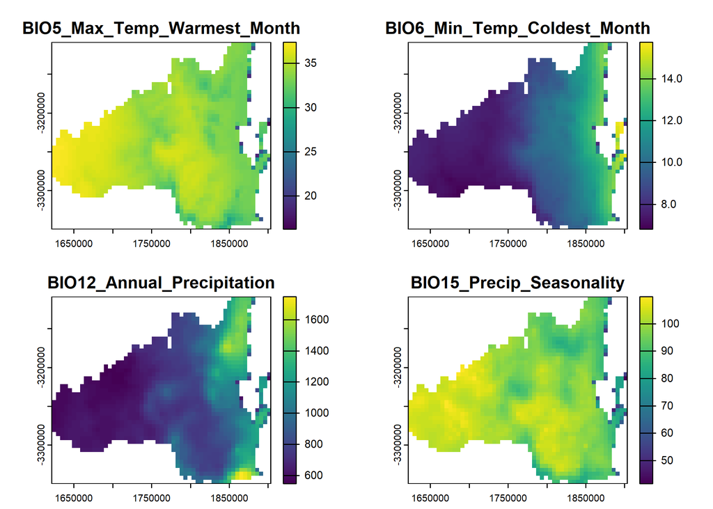

```r
plot(covs_future_expert)
```

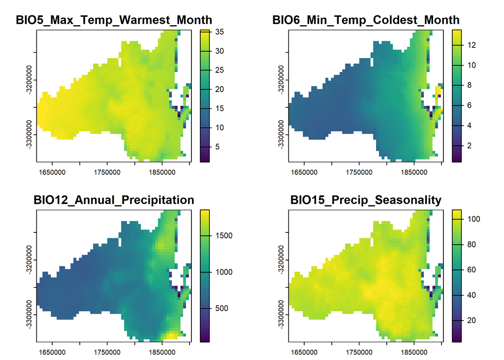

```r
plot(covs_future_SSP126_expert)
```

## GLM future predictions (SSP 1.26)

### Model 1

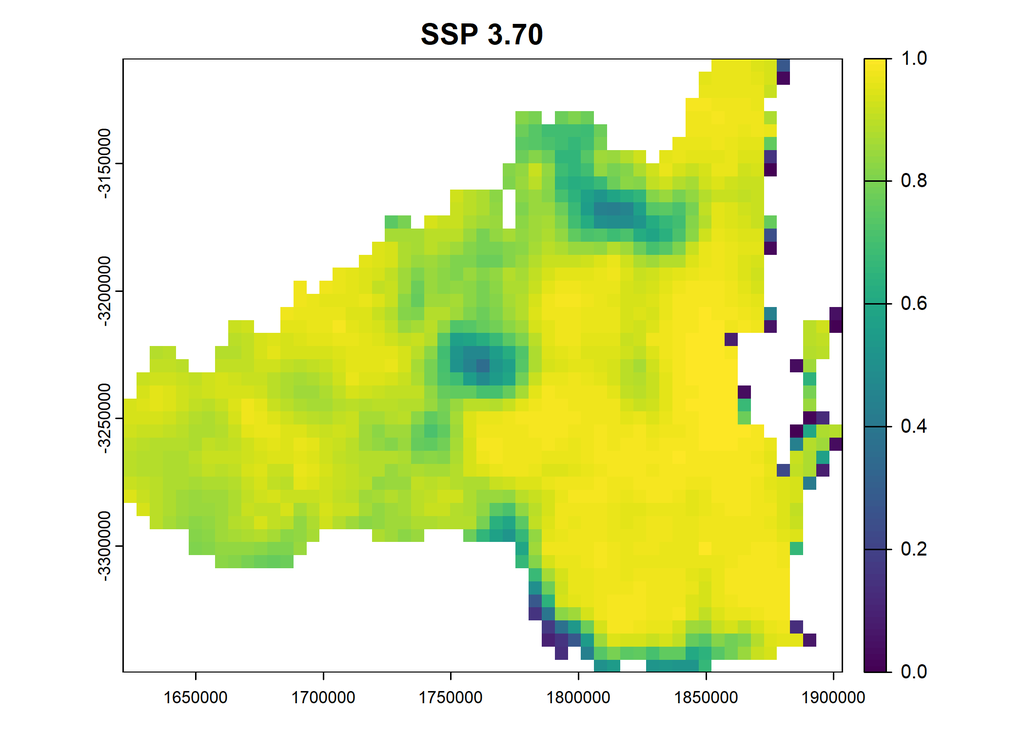

```r
# Predict the presence probability across the entire raster extent
predicted_raster_model_1_SSP126 <- predict(covs_future_SSP126_expert, glm_model_1, type = "response")

# Plot the species distribution raster
plot(
  predicted_raster_model_1,
  range = c(0,1),
  main = "SSP 3.70"
)
```

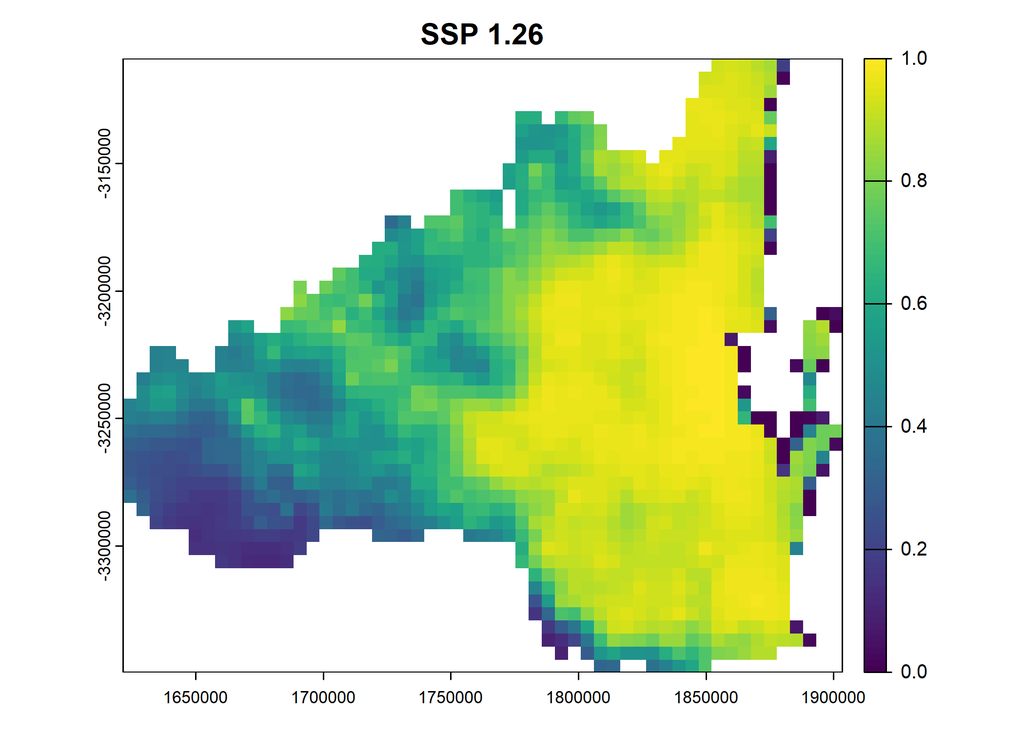

```r
plot(
  predicted_raster_model_1_SSP126,
  range = c(0,1),
  main = "SSP 1.26"
)
```

## Model uncertainty

Another element of uncertainty that can be represented is model uncertainty, or the standard error around the coefficient estimates.

```r
# Extract standard errors of coefficients

coef_se <- summary(glm_model_1)$coefficients[, "Std. Error"]

print(coef_se)
```

```
                (Intercept) BIO5_Max_Temp_Warmest_Month
               1.8309270981                0.0592126064
BIO6_Min_Temp_Coldest_Month  BIO12_Annual_Precipitation
               0.0360833444                0.0003325515
   BIO15_Precip_Seasonality
               0.0126551469
```

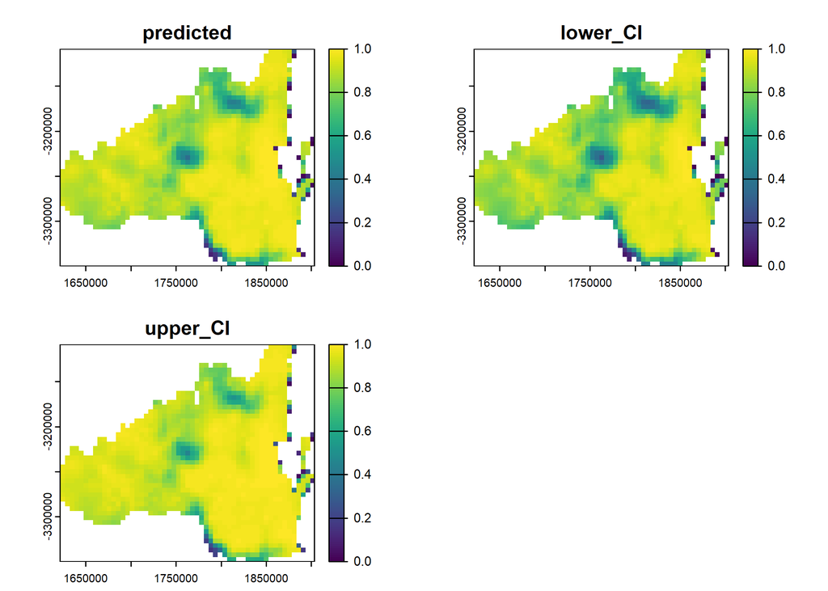

```r
covs_df <- as.data.frame(covs_future_expert, na.rm = FALSE)

pred_link <- predict(glm_model_1, newdata = covs_df, type = "link", se.fit = TRUE)

# Linear predictor (eta)
eta <- pred_link$fit
se_eta <- pred_link$se.fit

# Confidence intervals (95%)
z <- 1.96
eta_lower <- eta - z * se_eta
eta_upper <- eta + z * se_eta

# Transform back to response scale
linkinv <- glm_model_1$family$linkinv
predicted <- linkinv(eta)
lower_ci <- linkinv(eta_lower)
upper_ci <- linkinv(eta_upper)


# Add to covs_df
covs_df$predicted <- predicted
covs_df$lower_ci <- lower_ci
covs_df$upper_ci <- upper_ci


predicted_r <- setValues(rast(covs_future_expert, nlyr = 1), predicted)
lower_ci_r <- setValues(rast(covs_future_expert, nlyr = 1), lower_ci)
upper_ci_r <- setValues(rast(covs_future_expert, nlyr = 1), upper_ci)

# Step 2: Name the layers
names(predicted_r) <- "predicted"
names(lower_ci_r) <- "lower_CI"
names(upper_ci_r) <- "upper_CI"

prediction_w_uncertainty <- c(predicted_r, lower_ci_r, upper_ci_r)

plot(prediction_w_uncertainty, range = c(0, 1))
```